# Notebook L01: Data Preprocessing and Feature Engineering for Credit Risk Modeling

## Introduction

Credit risk modeling is a crucial component for financial institutions to effectively manage and mitigate the risk of borrower default on loans, credit cards, or other types of credit products. This risk arises when borrowers are unable to repay the full amount owed, including principal and interest, sometimes making only partial payments. To address this, financial institutions leverage both statistical and machine learning techniques to build robust predictive models that assess creditworthiness, manage exposure, and comply with regulatory standards.

### Key Concepts and Formulas

In credit risk management, the Internal Ratings-Based (IRB) approach is widely used, with two main variants:

- **Foundation IRB:** Where Probability of Default (PD) is internally estimated by the bank, while Loss Given Default (LGD) and Exposure at Default (EAD) values are prescribed by regulators.
- **Advanced IRB:** Where PD, LGD, and EAD are all estimated internally by the bank using advanced models.

Key definitions are:

- **Probability of Default (PD):** The likelihood that a borrower will default on their loan within a one-year horizon, often modeled using logistic regression. It is expressed as a percentage between 0% and 100%, indicating the borrower's risk level.
- **Loss Given Default (LGD):** The proportion of the exposure that is lost if a borrower defaults. It is calculated as $LGD = 1 - \text{Recovery Rate}$ and is commonly modeled using beta regression.
- **Exposure at Default (EAD):** The total value the bank is exposed to when a borrower defaults. It estimates the outstanding amount at the time of default and is also modeled with beta or linear regression techniques.
- **Expected Loss (EL):** The anticipated average loss due to default, computed as:

$$ \text{EL} = \text{PD} \times \text{LGD} \times \text{EAD} $$

This formula integrates the three core risk components into a single metric used for capital allocation, pricing, and risk management.

### Types of Credit Risk Models

Credit risk modeling can be divided broadly into two types:

1. **Application Models:**
   - Used to decide whether to grant a loan and at what interest rate.
   - Employ risk-based pricing where higher risk leads to higher interest rates.
2. **Behavioral Models:**
   - Assess whether to extend additional credit to existing borrowers.
   - Often implemented via scorecards derived from PD models.

### Dataset Overview

The dataset utilized for this project contains over 800,000 consumer loans issued between 2007 and 2015 by Lending Club, a major US peer-to-peer lending platform. The dataset includes both discrete and continuous features that require careful preprocessing through fine and coarse classing, followed by conversion into dummy variables.

For modeling purposes, the data is split into two periods:

- Historical data (2007–2014): Used to build initial Expected Loss models.
- Recent data (2015): Used to validate and test model robustness on newer borrower profiles.

This temporal split allows evaluation of model stability and predictive power over time.

### Project Goal & Compliance

The main objective is to develop an AI-powered credit risk modeling pipeline compliant with Basel II regulatory frameworks, delivering:

- A practical scorecard derived from PD models for daily credit risk decisions.
- LGD and EAD models to estimate losses accurately.
- An integrated Expected Loss calculation pipeline.
- Model validation metrics, including Population Stability Index (PSI), to monitor model performance on recent data.

### Project Structure and Notebooks

- **Notebook L01:** Preprocessing and feature engineering — preparing data via fine/coarse classing and dummy variable creation.
- **Notebook L02:** PD modeling using logistic regression and scorecard development, including cutoff rate calculations.
- **Notebook L03:** LGD and EAD modeling using beta and linear regression; computing the Expected Loss metric.
- **Notebook L04:** Model validation through Population Stability Index and ongoing performance monitoring.

This project reflects my deep passion for credit risk analytics, combining rigorous statistical methodology with machine learning to build models that are not only predictive but also interpretable and aligned with regulatory expectations. By leveraging large-scale datasets and cutting-edge techniques, this work aims to empower financial institutions with reliable tools for better risk management and strategic decision-making.

### Summary

- Comprehensive data cleaning and transformation of raw Lending Club loan data.
- Intelligent categorical encoding through fine and coarse classing techniques.
- Strategic dataset split to mimic real-world credit risk assessment timelines.
- Preparation of clean, model-ready datasets for predictive modeling of PD, LGD, and EAD in subsequent notebooks.

## Importing Libraries

```python
#installing gdown package to download dataset stored in G Drive
!pip install gdown
# to upgrade
!pip install --upgrade gdown
```

```python
#data handling libs
import numpy as np
import pandas as pd

#lib to download the g-drive data
import gdown

#sklearn libs
from sklearn.model_selection import train_test_split

#data viz
import matplotlib.pyplot as plt
import seaborn as sns
sns.set()

#importing custom-made functions
import sys #importing local functions in src folder
sys.path.append('../src/')
from functions import *
```

## Importing Data

```python
#loading dataset from Gdrive
fname_2007etp = "https://drive.google.com/file/d/16JXrTBSgEJH4_30zlFFBye1GRHh5h4O0/view?usp=share_link"
fname_2007etp = 'https://drive.google.com/uc?id=' + fname_2007etp.split('/')[-2]

#updated dataset
#fname_2015 = "https://drive.google.com/file/d/1Fb7LFd97aJm0ySb0A48_znfe9KQzaUZO/view?usp=share_link"
#fname_2015 = 'https://drive.google.com/uc?id=' + fname_2015.split('/')[-2]
```

```python
# downloading gdrive files
url = fname_2007etp
output = "loan_data_2007_2014.csv"
gdown.download(url, output, quiet=False)
```

```
Downloading...
From (original): https://drive.google.com/uc?id=16JXrTBSgEJH4_30zlFFBye1GRHh5h4O0
From (redirected): https://drive.google.com/uc?id=16JXrTBSgEJH4_30zlFFBye1GRHh5h4O0&confirm=t&uuid=5374d591-818c-464d-bc6e-fa99e7e684a8
To: /Users/aish7/Documents/Credit_Risk_Modelling/notebooks/loan_data_2007_2014.csv
```

```
'loan_data_2007_2014.csv'
```

```python
loan_data= pd.read_csv(output)
```

## Exploring Data

```python
# Uncomment below to set the pandas dataframe options to display all columns/ rows.
#pd.options.display.max_columns = None
#pd.options.display.max_rows = None

loan_data.shape
```

```
(466285, 75)
```

```python
loan_data.head()
```

|  | Unnamed: 0 | id | member_id | loan_amnt | funded_amnt | funded_amnt_inv | term | int_rate | installment | grade | ... | total_bal_il | il_util | open_rv_12m | open_rv_24m | max_bal_bc | all_util | total_rev_hi_lim | inq_fi | total_cu_tl | inq_last_12m |
| --- | --- | --- | --- | --- | --- | --- | --- | --- | --- | --- | --- | --- | --- | --- | --- | --- | --- | --- | --- | --- | --- |
| 0 | 0 | 1077501 | 1296599 | 5000 | 5000 | 4975.0 | 36 months | 10.65 | 162.87 | B | ... | NaN | NaN | NaN | NaN | NaN | NaN | NaN | NaN | NaN | NaN |
| 1 | 1 | 1077430 | 1314167 | 2500 | 2500 | 2500.0 | 60 months | 15.27 | 59.83 | C | ... | NaN | NaN | NaN | NaN | NaN | NaN | NaN | NaN | NaN | NaN |
| 2 | 2 | 1077175 | 1313524 | 2400 | 2400 | 2400.0 | 36 months | 15.96 | 84.33 | C | ... | NaN | NaN | NaN | NaN | NaN | NaN | NaN | NaN | NaN | NaN |
| 3 | 3 | 1076863 | 1277178 | 10000 | 10000 | 10000.0 | 36 months | 13.49 | 339.31 | C | ... | NaN | NaN | NaN | NaN | NaN | NaN | NaN | NaN | NaN | NaN |
| 4 | 4 | 1075358 | 1311748 | 3000 | 3000 | 3000.0 | 60 months | 12.69 | 67.79 | B | ... | NaN | NaN | NaN | NaN | NaN | NaN | NaN | NaN | NaN | NaN |

5 rows × 75 columns

```python
loan_data.tail()
```

|  | Unnamed: 0 | id | member_id | loan_amnt | funded_amnt | funded_amnt_inv | term | int_rate | installment | grade | ... | total_bal_il | il_util | open_rv_12m | open_rv_24m | max_bal_bc | all_util | total_rev_hi_lim | inq_fi | total_cu_tl | inq_last_12m |
| --- | --- | --- | --- | --- | --- | --- | --- | --- | --- | --- | --- | --- | --- | --- | --- | --- | --- | --- | --- | --- | --- |
| 466280 | 466280 | 8598660 | 1440975 | 18400 | 18400 | 18400.0 | 60 months | 14.47 | 432.64 | C | ... | NaN | NaN | NaN | NaN | NaN | NaN | 29900.0 | NaN | NaN | NaN |
| 466281 | 466281 | 9684700 | 11536848 | 22000 | 22000 | 22000.0 | 60 months | 19.97 | 582.50 | D | ... | NaN | NaN | NaN | NaN | NaN | NaN | 39400.0 | NaN | NaN | NaN |
| 466282 | 466282 | 9584776 | 11436914 | 20700 | 20700 | 20700.0 | 60 months | 16.99 | 514.34 | D | ... | NaN | NaN | NaN | NaN | NaN | NaN | 13100.0 | NaN | NaN | NaN |
| 466283 | 466283 | 9604874 | 11457002 | 2000 | 2000 | 2000.0 | 36 months | 7.90 | 62.59 | A | ... | NaN | NaN | NaN | NaN | NaN | NaN | 53100.0 | NaN | NaN | NaN |
| 466284 | 466284 | 9199665 | 11061576 | 10000 | 10000 | 9975.0 | 36 months | 19.20 | 367.58 | D | ... | NaN | NaN | NaN | NaN | NaN | NaN | 16000.0 | NaN | NaN | NaN |

5 rows × 75 columns

```python
loan_data.columns.values
```

```
array(['Unnamed: 0', 'id', 'member_id', 'loan_amnt', 'funded_amnt',
       'funded_amnt_inv', 'term', 'int_rate', 'installment', 'grade',
       'sub_grade', 'emp_title', 'emp_length', 'home_ownership',
       'annual_inc', 'verification_status', 'issue_d', 'loan_status',
       'pymnt_plan', 'url', 'desc', 'purpose', 'title', 'zip_code',
       'addr_state', 'dti', 'delinq_2yrs', 'earliest_cr_line',
       'inq_last_6mths', 'mths_since_last_delinq',
       'mths_since_last_record', 'open_acc', 'pub_rec', 'revol_bal',
       'revol_util', 'total_acc', 'initial_list_status', 'out_prncp',
       'out_prncp_inv', 'total_pymnt', 'total_pymnt_inv',
       'total_rec_prncp', 'total_rec_int', 'total_rec_late_fee',
       'recoveries', 'collection_recovery_fee', 'last_pymnt_d',
       'last_pymnt_amnt', 'next_pymnt_d', 'last_credit_pull_d',
       'collections_12_mths_ex_med', 'mths_since_last_major_derog',
       'policy_code', 'application_type', 'annual_inc_joint', 'dti_joint',
       'verification_status_joint', 'acc_now_delinq', 'tot_coll_amt',
       'tot_cur_bal', 'open_acc_6m', 'open_il_6m', 'open_il_12m',
       'open_il_24m', 'mths_since_rcnt_il', 'total_bal_il', 'il_util',
       'open_rv_12m', 'open_rv_24m', 'max_bal_bc', 'all_util',
       'total_rev_hi_lim', 'inq_fi', 'total_cu_tl', 'inq_last_12m'],
      dtype=object)
```

```python
# Displaying column names with non missing cases and datatype
loan_data.info()
```

```
<class 'pandas.core.frame.DataFrame'>
RangeIndex: 466285 entries, 0 to 466284
Data columns (total 75 columns):
 #   Column                       Non-Null Count   Dtype
---  ------                       --------------   -----
 0   Unnamed: 0                   466285 non-null  int64
 1   id                           466285 non-null  int64
 2   member_id                    466285 non-null  int64
 3   loan_amnt                    466285 non-null  int64
 4   funded_amnt                  466285 non-null  int64
 5   funded_amnt_inv              466285 non-null  float64
 6   term                         466285 non-null  object
 7   int_rate                     466285 non-null  float64
 8   installment                  466285 non-null  float64
 9   grade                        466285 non-null  object
```

[output cut: 67 more lines]

After some trial and errors, we come up with the following columns that are found significant to be kept for the predictive models. Therefore, preprocessing will be applied solely on the following columns:

Attn: The preprocessing part is lengthy and takes some time to overview. However, it is repetitive and not complex.

**Discrete Variables**

1. 'grade': assigned loan grade
2. 'sub_grade': LC assigned loan subgrade taxliens
3. 'home_ownership': the home ownership status provided by the borrower during registration. Values are: RENT, OWN, MORTGAGE, OTHER.
4. addr_state: The state provided by the borrower in the loan application
5. 'verification_status': Indicates if the borrowers' joint income was verified by LC, not verified, or if the income source was verified
6. 'purpose': A category provided by the borrower for the loan request.
7. 'initial_list_status': The initial listing status of the loan. Possible values are – W, F

**Continuous Variables**

1. 'term': number of payments on the loan. Values are in months and can be either 36 or 60.
2. 'emp_length': Employment length in years. Possible values are between 0 and 10 where 0 means less than one year and 10 means ten or more years.
3. 'int_rate': Interest rate on the loan
4. 'mths_since_earliest_cr_line': date the borrower's earliest reported credit line was opened
5. 'delinq_2yrs': The number of 30+ days past-due incidences of delinquency in the borrower's credit file for the past 2 years
6. 'inq_last_6mths': The number of inquiries in past 6 months (excluding auto and mortgage inquiries)
7. 'open_acc': The number of open credit lines in the borrower's credit file
8. 'pub_rec' : Number of derogatory public records
9. 'total_acc': The total number of credit lines currently in the borrower's credit file
10. 'acc_now_delinq': The number of accounts on which the borrower is now delinquent.
11. 'total_rev_hi_lim': Total revolving high credit/credit limit
12. 'annual_inc': The self-reported annual income provided by the borrower during registration.
13. 'dti': A ratio calculated using the borrower’s total monthly debt payments on the total debt obligations, excluding mortgage and the requested LC loan, divided by the borrower’s self-reported monthly income.
14. 'mths_since_last_delinq': The number of months since the borrower's last delinquency.
15. 'mths_since_last_record': The number of months since the last public record.

Please note that the following column is not considered in the example herein but would have improved the prediction scores.

- 'mths_since_issue_d': Months since most recent issue d

# 2 General Preprocessing

## a Discrete variables - Dummy columns

```python
#creating dummy variables. adding new columns of values 1 or 0.
# ex for Gender=Male, we use 0 Non 1 True. etc
# single dummy variable is sufficient for two categories
# if there are 4 categories, we need only 3 categories in our prediction model
# we use the function
pd.get_dummies(loan_data['grade'], prefix = 'grade', prefix_sep = ':').head()
```

|  | grade:A | grade:B | grade:C | grade:D | grade:E | grade:F | grade:G |
| --- | --- | --- | --- | --- | --- | --- | --- |
| 0 | False | True | False | False | False | False | False |
| 1 | False | False | True | False | False | False | False |
| 2 | False | False | True | False | False | False | False |
| 3 | False | False | True | False | False | False | False |
| 4 | False | True | False | False | False | False | False |

```python
dummy_columns = ['grade','sub_grade','home_ownership','verification_status',
                 'loan_status','purpose','addr_state','initial_list_status']

df_Dummies = pd.DataFrame()
for col in dummy_columns:
  df_Dummy= pd.get_dummies(loan_data[col], prefix = col, prefix_sep = ':')
  df_Dummies = pd.concat([df_Dummies,df_Dummy ], axis=1)
  #print(loan_data_Dummies.head())
  # = pd.concat([loan_data,loan_data_Dummies],axis = 1)
```

```python
#list of all dummy columns.
df_Dummies.columns.values
```

```
array(['grade:A', 'grade:B', 'grade:C', 'grade:D', 'grade:E', 'grade:F',
       'grade:G', 'sub_grade:A1', 'sub_grade:A2', 'sub_grade:A3',
       'sub_grade:A4', 'sub_grade:A5', 'sub_grade:B1', 'sub_grade:B2',
       'sub_grade:B3', 'sub_grade:B4', 'sub_grade:B5', 'sub_grade:C1',
       'sub_grade:C2', 'sub_grade:C3', 'sub_grade:C4', 'sub_grade:C5',
       'sub_grade:D1', 'sub_grade:D2', 'sub_grade:D3', 'sub_grade:D4',
       'sub_grade:D5', 'sub_grade:E1', 'sub_grade:E2', 'sub_grade:E3',
       'sub_grade:E4', 'sub_grade:E5', 'sub_grade:F1', 'sub_grade:F2',
       'sub_grade:F3', 'sub_grade:F4', 'sub_grade:F5', 'sub_grade:G1',
       'sub_grade:G2', 'sub_grade:G3', 'sub_grade:G4', 'sub_grade:G5',
       'home_ownership:ANY', 'home_ownership:MORTGAGE',
       'home_ownership:NONE', 'home_ownership:OTHER',
       'home_ownership:OWN', 'home_ownership:RENT',
       'verification_status:Not Verified',
       'verification_status:Source Verified',
       'verification_status:Verified', 'loan_status:Charged Off',
       'loan_status:Current', 'loan_status:Default',
       'loan_status:Does not meet the credit policy. Status:Charged Off',
       'loan_status:Does not meet the credit policy. Status:Fully Paid',
       'loan_status:Fully Paid', 'loan_status:In Grace Period',
       'loan_status:Late (16-30 days)', 'loan_status:Late (31-120 days)',
       'purpose:car', 'purpose:credit_card', 'purpose:debt_consolidation',
       'purpose:educational', 'purpose:home_improvement', 'purpose:house',
       'purpose:major_purchase', 'purpose:medical', 'purpose:moving',
       'purpose:other', 'purpose:renewable_energy',
       'purpose:small_business', 'purpose:vacation', 'purpose:wedding',
       'addr_state:AK', 'addr_state:AL', 'addr_state:AR', 'addr_state:AZ',
       'addr_state:CA', 'addr_state:CO', 'addr_state:CT', 'addr_state:DC',
       'addr_state:DE', 'addr_state:FL', 'addr_state:GA', 'addr_state:HI',
       'addr_state:IA', 'addr_state:ID', 'addr_state:IL', 'addr_state:IN',
       'addr_state:KS', 'addr_state:KY', 'addr_state:LA', 'addr_state:MA',
       'addr_state:MD', 'addr_state:ME', 'addr_state:MI', 'addr_state:MN',
       'addr_state:MO', 'addr_state:MS', 'addr_state:MT', 'addr_state:NC',
       'addr_state:NE', 'addr_state:NH', 'addr_state:NJ', 'addr_state:NM',
       'addr_state:NV', 'addr_state:NY', 'addr_state:OH', 'addr_state:OK',
       'addr_state:OR', 'addr_state:PA', 'addr_state:RI', 'addr_state:SC',
       'addr_state:SD', 'addr_state:TN', 'addr_state:TX', 'addr_state:UT',
       'addr_state:VA', 'addr_state:VT', 'addr_state:WA', 'addr_state:WI',
       'addr_state:WV', 'addr_state:WY', 'initial_list_status:f',
       'initial_list_status:w'], dtype=object)
```

```python
#merging dummy columns with the main dataset
loan_data = pd.concat([loan_data,df_Dummies],axis = 1)
```

## b Continuous variables - Dt format conversion

```python
#lets convert emp_length into integer
loan_data['emp_length'].unique()
```

```
array(['10+ years', '< 1 year', '1 year', '3 years', '8 years', '9 years',
       '4 years', '5 years', '6 years', '2 years', '7 years', nan],
      dtype=object)
```

```python
loan_data['emp_length_int']= loan_data['emp_length'].str.replace('\+ years','')
loan_data['emp_length_int']= loan_data['emp_length_int'].str.replace('< 1 year',str(0))
loan_data['emp_length_int']= loan_data['emp_length_int'].str.replace('n/a',str(0))
loan_data['emp_length_int']= loan_data['emp_length_int'].str.replace(' years','')
loan_data['emp_length_int']= loan_data['emp_length_int'].str.replace(' year','')
```

```python
loan_data['emp_length_int'] = loan_data['emp_length_int'].replace({
    '10+': '10',
    '< 1 year': '0',
    'n/a': None
})

loan_data['emp_length_int'] = pd.to_numeric(loan_data['emp_length_int'], errors='coerce')
```

```python
# date variables not in dt format
loan_data['earliest_cr_line']
```

```
0         Jan-85
1         Apr-99
2         Nov-01
3         Feb-96
4         Jan-96
           ...
466280    Apr-03
466281    Jun-97
466282    Dec-01
466283    Feb-03
466284    Feb-00
Name: earliest_cr_line, Length: 466285, dtype: object
```

```python
# Convert the 'earliest_cr_line' column to datetime with format like 'Apr-03'
loan_data['earliest_cr_line_date'] = pd.to_datetime(loan_data['earliest_cr_line'], format='%b-%y')

# Calculate the difference in days between '2017-12-01' and the earliest credit line date
diff_cr_line = pd.to_datetime('2017-12-01') - loan_data['earliest_cr_line_date']

# Convert the difference to months (approximate using average days in a month)
loan_data['mths_since_earliest_cr_line'] = (diff_cr_line.dt.days / 30.44).round().astype('Int64')
```

```python
loan_data['mths_since_earliest_cr_line'].describe()
```

```
count     466256.0
mean     239.48243
std      93.974829
min         -612.0
25%          183.0
50%          225.0
75%          285.0
max          587.0
Name: mths_since_earliest_cr_line, dtype: Float64
```

```python
#finding out why there are negative values in our dataset
m1 = loan_data['mths_since_earliest_cr_line']<0
loan_data.loc[m1,['earliest_cr_line','earliest_cr_line_date','mths_since_earliest_cr_line']].head()
```

|  | earliest_cr_line | earliest_cr_line_date | mths_since_earliest_cr_line |
| --- | --- | --- | --- |
| 1580 | Sep-62 | 2062-09-01 | -537 |
| 1770 | Sep-68 | 2068-09-01 | -609 |
| 2799 | Sep-64 | 2064-09-01 | -561 |
| 3282 | Sep-67 | 2067-09-01 | -597 |
| 3359 | Feb-65 | 2065-02-01 | -566 |

```python
# it is neccessary to handle negative values. they are due to the 196x data read as 206x
# we take the maximum month difference to replace negative values
loan_data.loc[m1,'mths_since_earliest_cr_line'] = loan_data.loc[:,'mths_since_earliest_cr_line'].max()
```

```python
#let's convert term column to integer format
loan_data['term']
```

```
0          36 months
1          60 months
2          36 months
3          36 months
4          60 months
             ...
466280     60 months
466281     60 months
466282     60 months
466283     36 months
466284     36 months
Name: term, Length: 466285, dtype: object
```

```python
loan_data['term_int'] = loan_data['term'].str.replace(' months', '').astype(int)
loan_data['term_int'].describe()
```

```
count    466285.000000
mean         42.605334
std          10.719040
min          36.000000
25%          36.000000
50%          36.000000
75%          60.000000
max          60.000000
Name: term_int, dtype: float64
```

```python
# Convert 'issue_d' to datetime
loan_data['issue_d_date'] = pd.to_datetime(loan_data['issue_d'], format='%b-%y')

# Calculate difference in days between 2017-12-01 and 'issue_d_date'
diff_issue_d = pd.to_datetime('2017-12-01') - loan_data['issue_d_date']

# Convert difference to months (approximate)
loan_data['mths_since_issue_d'] = (diff_issue_d.dt.days / 30.44).round().astype('Int64')

# Show descriptive statistics
print(loan_data['mths_since_issue_d'].describe())
```

```
count     466285.0
mean     51.255187
std      14.340154
min           36.0
25%           41.0
50%           47.0
75%           57.0
max          126.0
Name: mths_since_issue_d, dtype: Float64
```

## c Checking for missing values or cleaning them

```python
pd.options.display.max_rows = None
loan_data.isnull().sum().sort_values(ascending=False)
```

```
open_il_6m                                                         466285
all_util                                                           466285
inq_fi                                                             466285
total_cu_tl                                                        466285
open_rv_24m                                                        466285
inq_last_12m                                                       466285
open_rv_12m                                                        466285
il_util                                                            466285
total_bal_il                                                       466285
max_bal_bc                                                         466285
mths_since_rcnt_il                                                 466285
open_il_24m                                                        466285
open_il_12m                                                        466285
open_acc_6m                                                        466285
verification_status_joint                                          466285
dti_joint                                                          466285
annual_inc_joint                                                   466285
mths_since_last_record                                             403647
mths_since_last_major_derog                                        367311
desc                                                               340304
mths_since_last_delinq                                             250351
next_pymnt_d                                                       227214
total_rev_hi_lim                                                    70276
tot_coll_amt                                                        70276
tot_cur_bal                                                         70276
emp_title                                                           27588
emp_length                                                          21008
emp_length_int                                                      21008
last_pymnt_d                                                          376
revol_util                                                            340
collections_12_mths_ex_med                                            145
last_credit_pull_d                                                     42
mths_since_earliest_cr_line                                            29
acc_now_delinq                                                         29
earliest_cr_line_date                                                  29
total_acc                                                              29
pub_rec                                                                29
open_acc                                                               29
inq_last_6mths                                                         29
earliest_cr_line                                                       29
```

[output cut: 153 more lines]

```
sub_grade:B2                                                            0
sub_grade:B3                                                            0
sub_grade:B4                                                            0
sub_grade:B5                                                            0
sub_grade:C1                                                            0
sub_grade:C2                                                            0
sub_grade:C3                                                            0
sub_grade:C4                                                            0
sub_grade:C5                                                            0
sub_grade:D1                                                            0
sub_grade:D2                                                            0
sub_grade:D3                                                            0
sub_grade:D4                                                            0
mths_since_issue_d                                                      0
dtype: int64
```

```python
# filling up the empty rows that will be used in our model.
# we use funded_amnt for the missing total_rev_hi_lim values
# fundedAmnt The total amount committed to that loan at that point in time.
loan_data['total_rev_hi_lim'].fillna(loan_data['funded_amnt'],inplace = True)
```

```python
# for the missing values in annual_inc, mean value is considered.
loan_data['annual_inc'].fillna(loan_data['annual_inc'].mean(),inplace = True)
```

```python
# for the missing values below, we consider 0
loan_data['mths_since_earliest_cr_line'].fillna(0,inplace = True)
loan_data['acc_now_delinq'].fillna(0, inplace=True)
loan_data['total_acc'].fillna(0, inplace=True)
loan_data['pub_rec'].fillna(0, inplace=True)
loan_data['open_acc'].fillna(0, inplace=True)
loan_data['inq_last_6mths'].fillna(0, inplace=True)
loan_data['delinq_2yrs'].fillna(0, inplace=True)
loan_data['emp_length_int'].fillna(0, inplace=True)
```

[output not shown]

# 3 PD Model Definition

Remember: EL = PD * LGB * EDA

First, we need to define the default definition. Good and bad definitions are needed

## a Data Preparation - Dependent Variable

Dependent variable. Good/Bad - Defaulted borrower Definition. Default and Non-default Accounts

```python
# let's explore loan_status column further and findout the proportion of data
loan_data['loan_status'].value_counts()
```

```
loan_status
Current                                                224226
Fully Paid                                             184739
Charged Off                                             42475
Late (31-120 days)                                       6900
In Grace Period                                          3146
Does not meet the credit policy. Status:Fully Paid       1988
Late (16-30 days)                                        1218
Default                                                   832
Does not meet the credit policy. Status:Charged Off       761
Name: count, dtype: int64
```

```python
loan_data['loan_status'].value_counts() / loan_data['loan_status'].count()
```

```
loan_status
Current                                                0.480878
Fully Paid                                             0.396193
Charged Off                                            0.091092
Late (31-120 days)                                     0.014798
In Grace Period                                        0.006747
Does not meet the credit policy. Status:Fully Paid     0.004263
Late (16-30 days)                                      0.002612
Default                                                0.001784
Does not meet the credit policy. Status:Charged Off    0.001632
Name: count, dtype: float64
```

```python
# if the result == 'Charged Off', 'Default', 'Does not meet the credit policy. Status: Charged Off.',
#                   'Late (31-120 days)', We take 0 (Bad). Otherwise = 1 (Good)
bad_def = ['Charged Off', 'Default','Does not meet the credit policy. Status: Charged Off.',
           'Late (31-120 days)']

#good is 1, bad is 0
loan_data['good_bad'] = np.where(loan_data['loan_status'].isin(bad_def), 0, 1)
```

```python
loan_data['good_bad'].head()
```

```
0    1
1    0
2    1
3    1
4    1
Name: good_bad, dtype: int64
```

```python
loan_data['good_bad'].value_counts() / loan_data['good_bad'].count()
```

```
good_bad
1    0.892326
0    0.107674
Name: count, dtype: float64
```

## **b Train n Test Set Split**

```python
#splitting data into test and split datasets. 80:20 train to test ratio
inputs_train, inputs_test, targets_train, targets_test = train_test_split(
    loan_data.drop('good_bad',axis = 1), loan_data['good_bad'], test_size=0.2,
    random_state= 75)
```

```python
inputs_train.shape
```

```
(373028, 207)
```

```python
inputs_test.shape
```

```
(93257, 207)
```

## **c Selecting test or train set for preproc.**

```python
#first run it for train set and then for test set for the preprocessing
df_inputs_prepr = inputs_train
df_targets_prepr = targets_train
#test set
#df_inputs_prepr = inputs_test
#df_targets_prepr = targets_test

#next we will calculate Weight of Evidence (WoE)
```

# 4 Discrete Data Preparation - WoE

**Let's automate the calculation of WoE and IV**

**Weight of Evidence- Woe** To what extent an independent variable would predict a dependent variable

Positive WOE means Distribution of Goods > Distribution of Bads  
Negative WOE means Distribution of Goods < Distribution of Bads  
Hint : Log of a number > 1 means positive value. If less than 1, it means negative value.

Two ways to classify groups in WoE calculations

1. Fine Classing: Create 10 to 20 bins/groups for a continuous independent variable and then calculate WOE and IV of the variable.
2. Coarse Classing: Combine adjacent categories with similar WOE scores

**Information Value (IV)**

Information value is a useful technique to select important variables in a predictive model. It represents how much independent information it brings originally to explain dependent value. It helps to rank variables on the basis of their importance. The IV is calculated using the following formula :

IV = ∑ (% of non-events - % of events) * WOE

IV categories

- Less than 0.02 => Not useful for prediction
- 0.02 to 0.1 => Weak predictive Power
- 0.1 to 0.3 => Medium predictive Power
- 0.3 to 0.5 => Strong predictive Power
- '>0.5 => Suspicious Predictive Power

## Part 1 Discrete Variables: Dummy Variables

```python
df_temp = woe_discrete(df_inputs_prepr, 'grade',df_targets_prepr)
df_temp
```

|  | grade | n_obs | prop_good | prop_n_obs | n_good | n_bad | prop_n_good | prop_n_bad | WoE | diff_prop_good | diff_WoE | IV |
| --- | --- | --- | --- | --- | --- | --- | --- | --- | --- | --- | --- | --- |
| 0 | G | 2657 | 0.750847 | 0.007123 | 1995.0 | 662.0 | 0.005992 | 0.016524 | -1.014478 | NaN | NaN | 0.278546 |
| 1 | F | 10436 | 0.764661 | 0.027976 | 7980.0 | 2456.0 | 0.023966 | 0.061305 | -0.939208 | 0.013814 | 0.075271 | 0.278546 |
| 2 | E | 28690 | 0.809934 | 0.076911 | 23237.0 | 5453.0 | 0.069788 | 0.136114 | -0.668032 | 0.045273 | 0.271176 | 0.278546 |
| 3 | D | 61459 | 0.848875 | 0.164757 | 52171.0 | 9288.0 | 0.156686 | 0.231841 | -0.391809 | 0.038941 | 0.276224 | 0.278546 |
| 4 | C | 100162 | 0.886434 | 0.268511 | 88787.0 | 11375.0 | 0.266655 | 0.283935 | -0.062790 | 0.037559 | 0.329019 | 0.278546 |
| 5 | B | 109728 | 0.922572 | 0.294155 | 101232.0 | 8496.0 | 0.304031 | 0.212071 | 0.360207 | 0.036138 | 0.422997 | 0.278546 |
| 6 | A | 59896 | 0.961066 | 0.160567 | 57564.0 | 2332.0 | 0.172883 | 0.058210 | 1.088559 | 0.038494 | 0.728352 | 0.278546 |

**Drawing the plots**

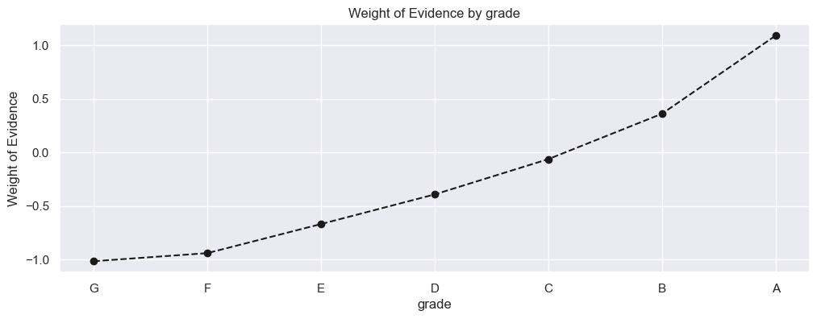

```python
plot_by_woe(df_temp,0)
```

As we can see, WoE increases with increasing external credit grade. That means loans with greater external grade are better in general.

```python
df_temp = woe_discrete(df_inputs_prepr, 'home_ownership',df_targets_prepr)
df_temp
```

|  | home_ownership | n_obs | prop_good | prop_n_obs | n_good | n_bad | prop_n_good | prop_n_bad | WoE | diff_prop_good | diff_WoE | IV |
| --- | --- | --- | --- | --- | --- | --- | --- | --- | --- | --- | --- | --- |
| 0 | NONE | 44 | 0.840909 | 0.000118 | 37.0 | 7.0 | 0.000111 | 0.000175 | -0.452604 | NaN | NaN | inf |
| 1 | OTHER | 130 | 0.853846 | 0.000348 | 111.0 | 19.0 | 0.000333 | 0.000474 | -0.352521 | 0.012937 | 0.100083 | inf |
| 2 | RENT | 150880 | 0.876445 | 0.404474 | 132238.0 | 18642.0 | 0.397152 | 0.465329 | -0.158426 | 0.022599 | 0.194095 | inf |
| 3 | OWN | 33428 | 0.893502 | 0.089613 | 29868.0 | 3560.0 | 0.089703 | 0.088862 | 0.009415 | 0.017058 | 0.167841 | inf |
| 4 | MORTGAGE | 188545 | 0.905413 | 0.505445 | 170711.0 | 17834.0 | 0.512698 | 0.445160 | 0.141253 | 0.011910 | 0.131838 | inf |
| 5 | ANY | 1 | 1.000000 | 0.000003 | 1.0 | 0.0 | 0.000003 | 0.000000 | inf | 0.094587 | inf | inf |

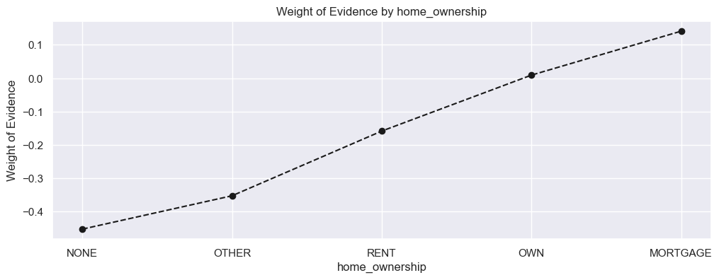

```python
plot_by_woe(df_temp,0)
```

We don't want dummy variables for None, Other and Any. They are undenrepresented categories.

Let's combine None, Other and Any

```python
df_inputs_prepr['home_ownership:RENT_OTHER_NONE_ANY'] = sum ([df_inputs_prepr['home_ownership:RENT'], df_inputs_prepr['home_ownership:OTHER'],
                                                              df_inputs_prepr['home_ownership:NONE'], df_inputs_prepr['home_ownership:ANY'],])
```

```python
df_inputs_prepr['addr_state'].unique()
```

```
array(['CA', 'IN', 'CO', 'MI', 'WA', 'AZ', 'NJ', 'VA', 'OR', 'TX', 'IL',
       'SC', 'FL', 'NY', 'SD', 'PA', 'MA', 'AL', 'NC', 'TN', 'MD', 'OH',
       'NH', 'GA', 'CT', 'MN', 'MO', 'WI', 'LA', 'NM', 'HI', 'NV', 'UT',
       'DE', 'OK', 'KS', 'MT', 'KY', 'AR', 'MS', 'WV', 'DC', 'RI', 'WY',
       'NE', 'VT', 'AK', 'ID', 'ME', 'IA'], dtype=object)
```

```python
df_temp = woe_discrete(df_inputs_prepr,'addr_state', df_targets_prepr)
df_temp
```

|  | addr_state | n_obs | prop_good | prop_n_obs | n_good | n_bad | prop_n_good | prop_n_bad | WoE | diff_prop_good | diff_WoE | IV |
| --- | --- | --- | --- | --- | --- | --- | --- | --- | --- | --- | --- | --- |
| 0 | NE | 13 | 0.615385 | 0.000035 | 8.0 | 5.0 | 0.000024 | 0.000125 | -1.647608 | NaN | NaN | inf |
| 1 | NV | 5174 | 0.868767 | 0.013870 | 4495.0 | 679.0 | 0.013500 | 0.016949 | -0.227512 | 0.253382 | 1.420096 | inf |
| 2 | HI | 1987 | 0.870659 | 0.005327 | 1730.0 | 257.0 | 0.005196 | 0.006415 | -0.210812 | 0.001892 | 0.016701 | inf |
| 3 | FL | 25289 | 0.878880 | 0.067794 | 22226.0 | 3063.0 | 0.066752 | 0.076456 | -0.135744 | 0.008221 | 0.075067 | inf |
| 4 | AL | 4668 | 0.879392 | 0.012514 | 4105.0 | 563.0 | 0.012329 | 0.014053 | -0.130931 | 0.000511 | 0.004813 | inf |
| 5 | LA | 4398 | 0.881764 | 0.011790 | 3878.0 | 520.0 | 0.011647 | 0.012980 | -0.108366 | 0.002373 | 0.022565 | inf |
| 6 | UT | 2764 | 0.884588 | 0.007410 | 2445.0 | 319.0 | 0.007343 | 0.007963 | -0.081003 | 0.002823 | 0.027363 | inf |
| 7 | NY | 32185 | 0.884667 | 0.086280 | 28473.0 | 3712.0 | 0.085513 | 0.092656 | -0.080227 | 0.000079 | 0.000776 | inf |
| 8 | NJ | 14503 | 0.886644 | 0.038879 | 12859.0 | 1644.0 | 0.038620 | 0.041036 | -0.060700 | 0.001977 | 0.019526 | inf |
| 9 | MO | 5958 | 0.886707 | 0.015972 | 5283.0 | 675.0 | 0.015866 | 0.016849 | -0.060075 | 0.000063 | 0.000625 | inf |
| 10 | SD | 768 | 0.886719 | 0.002059 | 681.0 | 87.0 | 0.002045 | 0.002172 | -0.059958 | 0.000012 | 0.000117 | inf |
| 11 | NM | 2079 | 0.886965 | 0.005573 | 1844.0 | 235.0 | 0.005538 | 0.005866 | -0.057505 | 0.000246 | 0.002453 | inf |
| 12 | MD | 8788 | 0.887233 | 0.023559 | 7797.0 | 991.0 | 0.023417 | 0.024737 | -0.054832 | 0.000268 | 0.002673 | inf |
| 13 | CA | 56993 | 0.887267 | 0.152785 | 50568.0 | 6425.0 | 0.151871 | 0.160376 | -0.054490 | 0.000034 | 0.000343 | inf |
| 14 | NC | 10156 | 0.887653 | 0.027226 | 9015.0 | 1141.0 | 0.027075 | 0.028481 | -0.050627 | 0.000386 | 0.003862 | inf |
| 15 | OK | 3322 | 0.887718 | 0.008905 | 2949.0 | 373.0 | 0.008857 | 0.009311 | -0.049969 | 0.000066 | 0.000658 | inf |
| 16 | VA | 11415 | 0.888480 | 0.030601 | 10142.0 | 1273.0 | 0.030460 | 0.031776 | -0.042303 | 0.000762 | 0.007666 | inf |
| 17 | ID | 9 | 0.888889 | 0.000024 | 8.0 | 1.0 | 0.000024 | 0.000025 | -0.038171 | 0.000409 | 0.004133 | inf |
| 18 | TN | 4721 | 0.889007 | 0.012656 | 4197.0 | 524.0 | 0.012605 | 0.013080 | -0.036979 | 0.000118 | 0.001192 | inf |
| 19 | AR | 2773 | 0.890371 | 0.007434 | 2469.0 | 304.0 | 0.007415 | 0.007588 | -0.023071 | 0.001365 | 0.013907 | inf |
| 20 | PA | 13243 | 0.890659 | 0.035501 | 11795.0 | 1448.0 | 0.035424 | 0.036144 | -0.020120 | 0.000288 | 0.002952 | inf |
| 21 | MI | 9311 | 0.890667 | 0.024961 | 8293.0 | 1018.0 | 0.024906 | 0.025411 | -0.020040 | 0.000008 | 0.000079 | inf |
| 22 | AZ | 8583 | 0.891530 | 0.023009 | 7652.0 | 931.0 | 0.022981 | 0.023239 | -0.011149 | 0.000863 | 0.008891 | inf |
| 23 | OH | 12183 | 0.892966 | 0.032660 | 10879.0 | 1304.0 | 0.032673 | 0.032550 | 0.003786 | 0.001436 | 0.014935 | inf |
| 24 | MN | 6482 | 0.893089 | 0.017377 | 5789.0 | 693.0 | 0.017386 | 0.017298 | 0.005073 | 0.000123 | 0.001287 | inf |
| 25 | IN | 5210 | 0.896929 | 0.013967 | 4673.0 | 537.0 | 0.014034 | 0.013404 | 0.045946 | 0.003840 | 0.040874 | inf |
| 26 | KY | 3491 | 0.897451 | 0.009359 | 3133.0 | 358.0 | 0.009409 | 0.008936 | 0.051601 | 0.000522 | 0.005655 | inf |
| 27 | MA | 8886 | 0.897817 | 0.023821 | 7978.0 | 908.0 | 0.023960 | 0.022665 | 0.055587 | 0.000366 | 0.003985 | inf |
| 28 | RI | 1621 | 0.898211 | 0.004346 | 1456.0 | 165.0 | 0.004373 | 0.004119 | 0.059891 | 0.000394 | 0.004304 | inf |
| 29 | WA | 8468 | 0.898914 | 0.022701 | 7612.0 | 856.0 | 0.022861 | 0.021367 | 0.067599 | 0.000703 | 0.007708 | inf |
| 30 | GA | 11916 | 0.899799 | 0.031944 | 10722.0 | 1194.0 | 0.032201 | 0.029804 | 0.077377 | 0.000885 | 0.009778 | inf |
| 31 | OR | 4800 | 0.901042 | 0.012868 | 4325.0 | 475.0 | 0.012989 | 0.011857 | 0.091240 | 0.001243 | 0.013864 | inf |
| 32 | WI | 4715 | 0.904136 | 0.012640 | 4263.0 | 452.0 | 0.012803 | 0.011283 | 0.126434 | 0.003094 | 0.035194 | inf |
| 33 | DE | 1026 | 0.905458 | 0.002750 | 929.0 | 97.0 | 0.002790 | 0.002421 | 0.141786 | 0.001322 | 0.015352 | inf |
| 34 | TX | 29280 | 0.906352 | 0.078493 | 26538.0 | 2742.0 | 0.079702 | 0.068444 | 0.152278 | 0.000894 | 0.010492 | inf |
| 35 | IL | 14909 | 0.907774 | 0.039968 | 13534.0 | 1375.0 | 0.040647 | 0.034322 | 0.169139 | 0.001421 | 0.016861 | inf |
| 36 | CO | 7762 | 0.908400 | 0.020808 | 7051.0 | 711.0 | 0.021176 | 0.017747 | 0.176640 | 0.000626 | 0.007501 | inf |
| 37 | IA | 11 | 0.909091 | 0.000029 | 10.0 | 1.0 | 0.000030 | 0.000025 | 0.184973 | 0.000691 | 0.008333 | inf |
| 38 | SC | 4470 | 0.909172 | 0.011983 | 4064.0 | 406.0 | 0.012205 | 0.010134 | 0.185958 | 0.000081 | 0.000985 | inf |
| 39 | AK | 1014 | 0.909270 | 0.002718 | 922.0 | 92.0 | 0.002769 | 0.002296 | 0.187145 | 0.000098 | 0.001187 | inf |
| 40 | CT | 5771 | 0.909548 | 0.015471 | 5249.0 | 522.0 | 0.015764 | 0.013030 | 0.190513 | 0.000278 | 0.003369 | inf |
| 41 | KS | 3357 | 0.910039 | 0.008999 | 3055.0 | 302.0 | 0.009175 | 0.007538 | 0.196496 | 0.000491 | 0.005983 | inf |
| 42 | MT | 1104 | 0.910326 | 0.002960 | 1005.0 | 99.0 | 0.003018 | 0.002471 | 0.200011 | 0.000287 | 0.003515 | inf |
| 43 | NH | 1780 | 0.914045 | 0.004772 | 1627.0 | 153.0 | 0.004886 | 0.003819 | 0.246443 | 0.003719 | 0.046432 | inf |
| 44 | VT | 748 | 0.918449 | 0.002005 | 687.0 | 61.0 | 0.002063 | 0.001523 | 0.303848 | 0.004404 | 0.057405 | inf |
| 45 | MS | 964 | 0.919087 | 0.002584 | 886.0 | 78.0 | 0.002661 | 0.001947 | 0.312396 | 0.000638 | 0.008548 | inf |
| 46 | WV | 1927 | 0.921640 | 0.005166 | 1776.0 | 151.0 | 0.005334 | 0.003769 | 0.347227 | 0.002553 | 0.034831 | inf |
| 47 | WY | 902 | 0.924612 | 0.002418 | 834.0 | 68.0 | 0.002505 | 0.001697 | 0.389114 | 0.002972 | 0.041887 | inf |
| 48 | DC | 1128 | 0.934397 | 0.003024 | 1054.0 | 74.0 | 0.003165 | 0.001847 | 0.538671 | 0.009785 | 0.149557 | inf |
| 49 | ME | 3 | 1.000000 | 0.000008 | 3.0 | 0.0 | 0.000009 | 0.000000 | inf | 0.065603 | inf | inf |

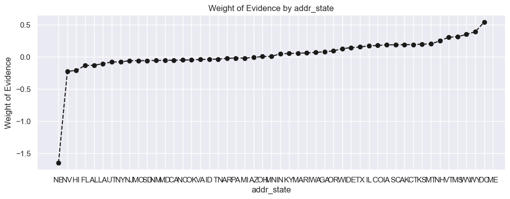

```python
plot_by_woe(df_temp)
```

```python
if ['addr_state:ND'] in df_inputs_prepr.columns.values:
  pass
else:
  df_inputs_prepr['addr_state:ND'] = 0
```

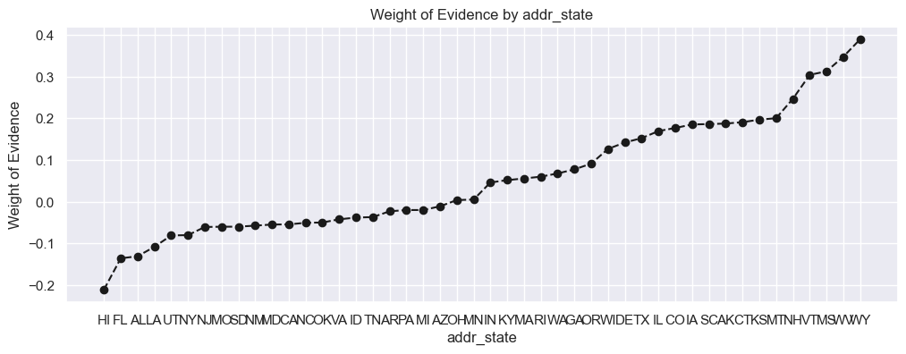

```python
plot_by_woe(df_temp.iloc[2:-2,:])
```

Lets combine Nevada with Florida. NE, IA, NV => FL

If no data, go with the worst case scenario.

Last 4 cols can be regrouped together.

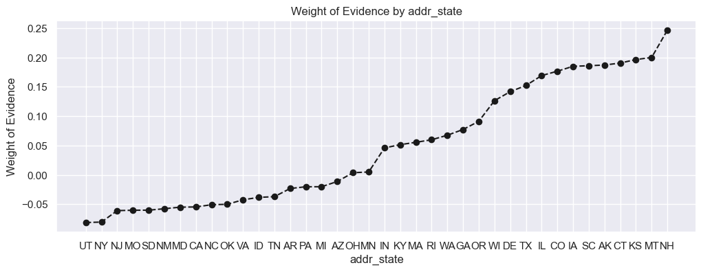

```python
plot_by_woe(df_temp.iloc[6:-6,:])
```

rest of the states can be in the same group. We can seperate NY and CA.

check with the borrowers, try to regroup some states together.

TX also has high number of borrowers.

```python
# We create the following categories:
# 'ND' 'NE' 'IA' NV' 'FL' 'HI' 'AL'
# 'NM' 'VA'
# 'NY'
# 'OK' 'TN' 'MO' 'LA' 'MD' 'NC'
# 'CA'
# 'UT' 'KY' 'AZ' 'NJ'
# 'AR' 'MI' 'PA' 'OH' 'MN'
# 'RI' 'MA' 'DE' 'SD' 'IN'
# 'GA' 'WA' 'OR'
# 'WI' 'MT'
# 'TX'
# 'IL' 'CT'
# 'KS' 'SC' 'CO' 'VT' 'AK' 'MS'
# 'WV' 'NH' 'WY' 'DC' 'ME' 'ID'

# 'IA_NV_HI_ID_AL_FL' will be the reference category.

df_inputs_prepr['addr_state:ND_NE_IA_NV_FL_HI_AL'] = sum([df_inputs_prepr['addr_state:ND'], df_inputs_prepr['addr_state:NE'],
                                              df_inputs_prepr['addr_state:IA'], df_inputs_prepr['addr_state:NV'],
                                              df_inputs_prepr['addr_state:FL'], df_inputs_prepr['addr_state:HI'],
                                                          df_inputs_prepr['addr_state:AL']])

df_inputs_prepr['addr_state:NM_VA'] = sum([df_inputs_prepr['addr_state:NM'], df_inputs_prepr['addr_state:VA']])

df_inputs_prepr['addr_state:OK_TN_MO_LA_MD_NC'] = sum([df_inputs_prepr['addr_state:OK'], df_inputs_prepr['addr_state:TN'],
                                              df_inputs_prepr['addr_state:MO'], df_inputs_prepr['addr_state:LA'],
                                              df_inputs_prepr['addr_state:MD'], df_inputs_prepr['addr_state:NC']])

df_inputs_prepr['addr_state:UT_KY_AZ_NJ'] = sum([df_inputs_prepr['addr_state:UT'], df_inputs_prepr['addr_state:KY'],
                                              df_inputs_prepr['addr_state:AZ'], df_inputs_prepr['addr_state:NJ']])

df_inputs_prepr['addr_state:AR_MI_PA_OH_MN'] = sum([df_inputs_prepr['addr_state:AR'], df_inputs_prepr['addr_state:MI'],
                                              df_inputs_prepr['addr_state:PA'], df_inputs_prepr['addr_state:OH'],
                                              df_inputs_prepr['addr_state:MN']])

df_inputs_prepr['addr_state:RI_MA_DE_SD_IN'] = sum([df_inputs_prepr['addr_state:RI'], df_inputs_prepr['addr_state:MA'],
                                              df_inputs_prepr['addr_state:DE'], df_inputs_prepr['addr_state:SD'],
                                              df_inputs_prepr['addr_state:IN']])

df_inputs_prepr['addr_state:GA_WA_OR'] = sum([df_inputs_prepr['addr_state:GA'], df_inputs_prepr['addr_state:WA'],
                                              df_inputs_prepr['addr_state:OR']])

df_inputs_prepr['addr_state:WI_MT'] = sum([df_inputs_prepr['addr_state:WI'], df_inputs_prepr['addr_state:MT']])

df_inputs_prepr['addr_state:IL_CT'] = sum([df_inputs_prepr['addr_state:IL'], df_inputs_prepr['addr_state:CT']])

df_inputs_prepr['addr_state:KS_SC_CO_VT_AK_MS'] = sum([df_inputs_prepr['addr_state:KS'], df_inputs_prepr['addr_state:SC'],
                                              df_inputs_prepr['addr_state:CO'], df_inputs_prepr['addr_state:VT'],
                                              df_inputs_prepr['addr_state:AK'], df_inputs_prepr['addr_state:MS']])

df_inputs_prepr['addr_state:WV_NH_WY_DC_ME_ID'] = sum([df_inputs_prepr['addr_state:WV'], df_inputs_prepr['addr_state:NH'],
                                              df_inputs_prepr['addr_state:WY'], df_inputs_prepr['addr_state:DC'],
                                              df_inputs_prepr['addr_state:ME'], df_inputs_prepr['addr_state:ID']])
```

## Part 2 Discrete Variables: Dummy Variables

**Let's repeat the same preprocessing on verification_status**

```python
# 'verification_status'
df_temp = woe_discrete(df_inputs_prepr, 'verification_status', df_targets_prepr)
# We calculate weight of evidence.
df_temp
```

|  | verification_status | n_obs | prop_good | prop_n_obs | n_good | n_bad | prop_n_good | prop_n_bad | WoE | diff_prop_good | diff_WoE | IV |
| --- | --- | --- | --- | --- | --- | --- | --- | --- | --- | --- | --- | --- |
| 0 | Verified | 134645 | 0.873943 | 0.360951 | 117672.0 | 16973.0 | 0.353405 | 0.423668 | -0.181335 | NaN | NaN | 0.023945 |
| 1 | Source Verified | 119854 | 0.896933 | 0.321300 | 107501.0 | 12353.0 | 0.322859 | 0.308347 | 0.045989 | 0.02299 | 0.227324 | 0.023945 |
| 2 | Not Verified | 118529 | 0.909423 | 0.317748 | 107793.0 | 10736.0 | 0.323736 | 0.267985 | 0.188998 | 0.01249 | 0.143009 | 0.023945 |

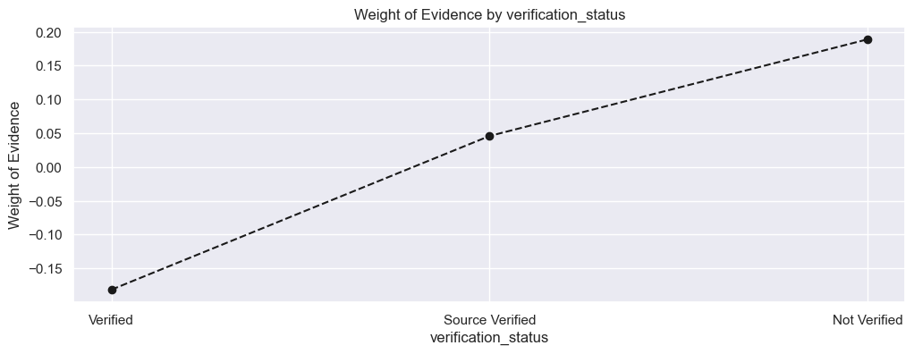

```python
plot_by_woe(df_temp)
# We plot the weight of evidence values.
```

OK **How about purpose row?

```python
# 'purpose'
df_temp = woe_discrete(df_inputs_prepr, 'purpose', df_targets_prepr)
# We calculate weight of evidence.
df_temp
```

|  | purpose | n_obs | prop_good | prop_n_obs | n_good | n_bad | prop_n_good | prop_n_bad | WoE | diff_prop_good | diff_WoE | IV |
| --- | --- | --- | --- | --- | --- | --- | --- | --- | --- | --- | --- | --- |
| 0 | small_business | 5632 | 0.795099 | 0.015098 | 4478.0 | 1154.0 | 0.013449 | 0.028805 | -0.761670 | NaN | NaN | 0.032998 |
| 1 | moving | 2378 | 0.848612 | 0.006375 | 2018.0 | 360.0 | 0.006061 | 0.008986 | -0.393854 | 0.053513 | 0.367816 | 0.032998 |
| 2 | renewable_energy | 287 | 0.850174 | 0.000769 | 244.0 | 43.0 | 0.000733 | 0.001073 | -0.381644 | 0.001562 | 0.012210 | 0.032998 |
| 3 | house | 1802 | 0.865150 | 0.004831 | 1559.0 | 243.0 | 0.004682 | 0.006066 | -0.258874 | 0.014976 | 0.122770 | 0.032998 |
| 4 | other | 19002 | 0.867698 | 0.050940 | 16488.0 | 2514.0 | 0.049519 | 0.062753 | -0.236854 | 0.002548 | 0.022019 | 0.032998 |
| 5 | medical | 3664 | 0.871179 | 0.009822 | 3192.0 | 472.0 | 0.009587 | 0.011782 | -0.206188 | 0.003481 | 0.030666 | 0.032998 |
| 6 | educational | 337 | 0.872404 | 0.000903 | 294.0 | 43.0 | 0.000883 | 0.001073 | -0.195232 | 0.001225 | 0.010956 | 0.032998 |
| 7 | debt_consolidation | 219381 | 0.888135 | 0.588109 | 194840.0 | 24541.0 | 0.585165 | 0.612576 | -0.045779 | 0.015732 | 0.149454 | 0.032998 |
| 8 | vacation | 1992 | 0.889056 | 0.005340 | 1771.0 | 221.0 | 0.005319 | 0.005516 | -0.036475 | 0.000921 | 0.009303 | 0.032998 |
| 9 | wedding | 1880 | 0.890957 | 0.005040 | 1675.0 | 205.0 | 0.005031 | 0.005117 | -0.017054 | 0.001901 | 0.019422 | 0.032998 |
| 10 | home_improvement | 21213 | 0.903314 | 0.056867 | 19162.0 | 2051.0 | 0.057549 | 0.051196 | 0.116990 | 0.012357 | 0.134043 | 0.032998 |
| 11 | major_purchase | 7802 | 0.909510 | 0.020915 | 7096.0 | 706.0 | 0.021311 | 0.017623 | 0.190059 | 0.006196 | 0.073070 | 0.032998 |
| 12 | car | 4315 | 0.914021 | 0.011567 | 3944.0 | 371.0 | 0.011845 | 0.009261 | 0.246137 | 0.004510 | 0.056077 | 0.032998 |
| 13 | credit_card | 83343 | 0.914354 | 0.223423 | 76205.0 | 7138.0 | 0.228867 | 0.178174 | 0.250382 | 0.000333 | 0.004246 | 0.032998 |

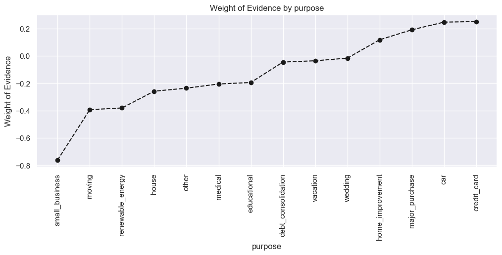

```python
plot_by_woe(df_temp, 90)
# We plot the weight of evidence values.
```

```python
# We combine 'educational', 'small_business', 'wedding', 'renewable_energy', 'moving', 'house' in one category: 'educ__sm_b__wedd__ren_en__mov__house'.
# We combine 'other', 'medical', 'vacation' in one category: 'oth__med__vacation'.
# We combine 'major_purchase', 'car', 'home_improvement' in one category: 'major_purch__car__home_impr'.
# We leave 'debt_consolidtion' in a separate category.
# We leave 'credit_card' in a separate category.
# 'educ__sm_b__wedd__ren_en__mov__house' will be the reference category.
df_inputs_prepr['purpose:educ__sm_b__wedd__ren_en__mov__house'] = sum([df_inputs_prepr['purpose:educational'], df_inputs_prepr['purpose:small_business'],
                                                                 df_inputs_prepr['purpose:wedding'], df_inputs_prepr['purpose:renewable_energy'],
                                                                 df_inputs_prepr['purpose:moving'], df_inputs_prepr['purpose:house']])
df_inputs_prepr['purpose:oth__med__vacation'] = sum([df_inputs_prepr['purpose:other'], df_inputs_prepr['purpose:medical'],
                                             df_inputs_prepr['purpose:vacation']])
df_inputs_prepr['purpose:major_purch__car__home_impr'] = sum([df_inputs_prepr['purpose:major_purchase'], df_inputs_prepr['purpose:car'],
                                                        df_inputs_prepr['purpose:home_improvement']])
```

**initial list status***

```python
# 'initial_list_status'
df_temp = woe_discrete(df_inputs_prepr, 'initial_list_status', df_targets_prepr)
df_temp
```

|  | initial_list_status | n_obs | prop_good | prop_n_obs | n_good | n_bad | prop_n_good | prop_n_bad | WoE | diff_prop_good | diff_WoE | IV |
| --- | --- | --- | --- | --- | --- | --- | --- | --- | --- | --- | --- | --- |
| 0 | f | 242477 | 0.882574 | 0.650024 | 214004.0 | 28473.0 | 0.64272 | 0.710723 | -0.100574 | NaN | NaN | 0.021197 |
| 1 | w | 130551 | 0.911230 | 0.349976 | 118962.0 | 11589.0 | 0.35728 | 0.289277 | 0.211136 | 0.028656 | 0.311709 | 0.021197 |

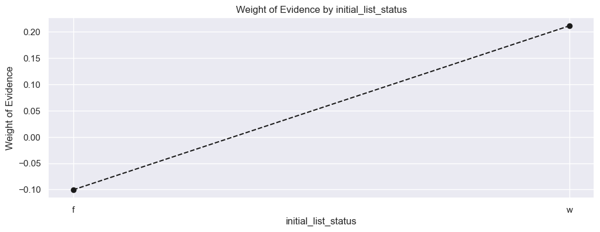

```python
plot_by_woe(df_temp)
# We plot the weight of evidence values.
```

# 5 Continous Data Preparation - WoE

```python
df_inputs_prepr['term_int'].unique()
```

```
array([36, 60])
```

```python
df_temp = woe_ordered_continuous ( df_inputs_prepr, 'term_int', df_targets_prepr)
df_temp
```

|  | term_int | n_obs | prop_good | prop_n_obs | n_good | n_bad | prop_n_good | prop_n_bad | WoE | diff_prop_good | diff_WoE | IV |
| --- | --- | --- | --- | --- | --- | --- | --- | --- | --- | --- | --- | --- |
| 0 | 36 | 270458 | 0.905061 | 0.725034 | 244781.0 | 25677.0 | 0.735153 | 0.640932 | 0.137156 | NaN | NaN | 0.0416 |
| 1 | 60 | 102570 | 0.859754 | 0.274966 | 88185.0 | 14385.0 | 0.264847 | 0.359068 | -0.304361 | 0.045307 | 0.441517 | 0.0416 |

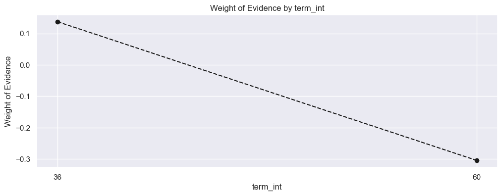

```python
plot_by_woe(df_temp)
```

```python
df_inputs_prepr['term:36'] = np.where((df_inputs_prepr['term_int']==36),1,0)
df_inputs_prepr['term:60'] = np.where((df_inputs_prepr['term_int']==60),1,0)
```

```python
df_inputs_prepr['emp_length_int'].unique()
```

```
array([ 4., 10.,  3.,  0.,  8.,  1.,  5.,  2.,  7.,  6.,  9.])
```

```python
df_temp = woe_ordered_continuous (df_inputs_prepr,'emp_length_int',df_targets_prepr)
df_temp
```

|  | emp_length_int | n_obs | prop_good | prop_n_obs | n_good | n_bad | prop_n_good | prop_n_bad | WoE | diff_prop_good | diff_WoE | IV |
| --- | --- | --- | --- | --- | --- | --- | --- | --- | --- | --- | --- | --- |
| 0 | 0.0 | 45847 | 0.879970 | 0.122905 | 40344.0 | 5503.0 | 0.121166 | 0.137362 | -0.125463 | NaN | NaN | 0.005462 |
| 1 | 1.0 | 23806 | 0.890826 | 0.063818 | 21207.0 | 2599.0 | 0.063691 | 0.064874 | -0.018408 | 0.010856 | 0.107055 | 0.005462 |
| 2 | 2.0 | 33003 | 0.892646 | 0.088473 | 29460.0 | 3543.0 | 0.088478 | 0.088438 | 0.000447 | 0.001820 | 0.018855 | 0.005462 |
| 3 | 3.0 | 29279 | 0.892858 | 0.078490 | 26142.0 | 3137.0 | 0.078513 | 0.078304 | 0.002664 | 0.000212 | 0.002217 | 0.005462 |
| 4 | 4.0 | 22503 | 0.893170 | 0.060325 | 20099.0 | 2404.0 | 0.060364 | 0.060007 | 0.005924 | 0.000311 | 0.003260 | 0.005462 |
| 5 | 5.0 | 24522 | 0.886265 | 0.065738 | 21733.0 | 2789.0 | 0.065271 | 0.069617 | -0.064463 | 0.006904 | 0.070387 | 0.005462 |
| 6 | 6.0 | 20778 | 0.885552 | 0.055701 | 18400.0 | 2378.0 | 0.055261 | 0.059358 | -0.071521 | 0.000713 | 0.007058 | 0.005462 |
| 7 | 7.0 | 20934 | 0.889558 | 0.056119 | 18622.0 | 2312.0 | 0.055928 | 0.057711 | -0.031381 | 0.004006 | 0.040140 | 0.005462 |
| 8 | 8.0 | 17830 | 0.892092 | 0.047798 | 15906.0 | 1924.0 | 0.047771 | 0.048026 | -0.005322 | 0.002534 | 0.026059 | 0.005462 |
| 9 | 9.0 | 14368 | 0.888363 | 0.038517 | 12764.0 | 1604.0 | 0.038334 | 0.040038 | -0.043484 | 0.003729 | 0.038162 | 0.005462 |
| 10 | 10.0 | 120158 | 0.901222 | 0.322115 | 108289.0 | 11869.0 | 0.325225 | 0.296266 | 0.093261 | 0.012859 | 0.136745 | 0.005462 |

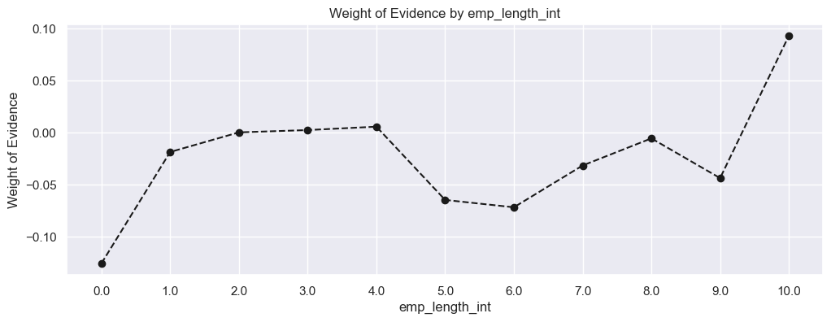

```python
plot_by_woe(df_temp)
```

```python
# We create the following categories: '0', '1', '2 - 4', '5 - 6', '7 - 9', '10'
# '0' will be the reference category
df_inputs_prepr['emp_length:0'] = np.where(df_inputs_prepr['emp_length_int'].isin([0]), 1, 0)
df_inputs_prepr['emp_length:1'] = np.where(df_inputs_prepr['emp_length_int'].isin([1]), 1, 0)
df_inputs_prepr['emp_length:2-4'] = np.where(df_inputs_prepr['emp_length_int'].isin(range(2, 5)), 1, 0)
df_inputs_prepr['emp_length:5-6'] = np.where(df_inputs_prepr['emp_length_int'].isin(range(5, 7)), 1, 0)
df_inputs_prepr['emp_length:7-9'] = np.where(df_inputs_prepr['emp_length_int'].isin(range(7, 10)), 1, 0)
df_inputs_prepr['emp_length:10'] = np.where(df_inputs_prepr['emp_length_int'].isin([10]), 1, 0)
```

## Part 1 Continous Variables - Dummy Variables

```python
df_inputs_prepr['mths_since_issue_d'].unique()
```

```
<IntegerArray>
[ 68,  42,  53,  41,  37,  63,  61,  56,  84,  57,  64,  70,  52,  47,  36,
  55,  45,  38,  40,  49,  58,  85,  54,  71,  44,  43,  62,  46,  48,  50,
  59,  51,  65,  96,  86,  72,  69,  91,  77,  82,  74, 110,  66,  80, 119,
  67,  99,  39, 116,  60,  73,  75, 100,  97,  76,  78,  94,  88,  81,  89,
  79,  87, 117, 113,  93,  98, 115, 122,  83, 106, 109, 112,  92,  95, 101,
 118,  90, 102, 103, 107, 104, 114, 121, 120, 105, 123, 108, 124, 111, 126,
 125]
Length: 91, dtype: Int64
```

```python
#let's do fine classing first: to roughly group the values into categories
#second, we need to do coarse classing: determining final categories, combining few of initial fine classing
# categories into bigger categories, if needed
df_inputs_prepr['mths_since_issue_d_factor'] = pd.cut(df_inputs_prepr['mths_since_issue_d'],50)
```

```python
df_inputs_prepr['mths_since_issue_d_factor'].head(20)
```

```
221233     (66.6, 68.4]
378461     (41.4, 43.2]
117522     (52.2, 54.0]
352107     (39.6, 41.4]
253931    (35.91, 37.8]
197856     (61.2, 63.0]
185307     (59.4, 61.2]
145527     (55.8, 57.6]
22919      (82.8, 84.6]
355028     (39.6, 41.4]
160609     (55.8, 57.6]
372833     (41.4, 43.2]
364006     (39.6, 41.4]
205790     (63.0, 64.8]
205119     (63.0, 64.8]
226521     (68.4, 70.2]
108093     (50.4, 52.2]
114304     (52.2, 54.0]
463381     (46.8, 48.6]
451532     (46.8, 48.6]
Name: mths_since_issue_d_factor, dtype: category
Categories (50, interval[float64, right]): [(35.91, 37.8] < (37.8, 39.6] < (39.6, 41.4] < (41.4, 43.2] ... (118.8, 120.6] < (120.6, 122.4] < (122.4, 124.2] < (124.2, 126.0]]
```

```python
df_temp = woe_ordered_continuous (df_inputs_prepr, 'mths_since_issue_d_factor',df_targets_prepr)
df_temp
```

|  | mths_since_issue_d_factor | n_obs | prop_good | prop_n_obs | n_good | n_bad | prop_n_good | prop_n_bad | WoE | diff_prop_good | diff_WoE | IV |
| --- | --- | --- | --- | --- | --- | --- | --- | --- | --- | --- | --- | --- |
| 0 | (35.91, 37.8] | 28321 | 0.943187 | 0.075922 | 26712.0 | 1609.0 | 0.080224 | 0.040163 | 0.691888 | NaN | NaN | inf |
| 1 | (37.8, 39.6] | 39625 | 0.928555 | 0.106225 | 36794.0 | 2831.0 | 0.110504 | 0.070665 | 0.447093 | 0.014632 | 0.244795 | inf |
| 2 | (39.6, 41.4] | 38418 | 0.916836 | 0.102990 | 35223.0 | 3195.0 | 0.105786 | 0.079751 | 0.282500 | 0.011719 | 0.164593 | inf |
| 3 | (41.4, 43.2] | 28945 | 0.908896 | 0.077595 | 26308.0 | 2637.0 | 0.079011 | 0.065823 | 0.182619 | 0.007940 | 0.099881 | inf |
| 4 | (43.2, 45.0] | 28278 | 0.902044 | 0.075807 | 25508.0 | 2770.0 | 0.076608 | 0.069143 | 0.102533 | 0.006852 | 0.080086 | inf |
| 5 | (45.0, 46.8] | 12219 | 0.900074 | 0.032756 | 10998.0 | 1221.0 | 0.033030 | 0.030478 | 0.080431 | 0.001970 | 0.022102 | inf |
| 6 | (46.8, 48.6] | 24532 | 0.898337 | 0.065765 | 22038.0 | 2494.0 | 0.066187 | 0.062254 | 0.061268 | 0.001737 | 0.019163 | inf |
| 7 | (48.6, 50.4] | 23000 | 0.887957 | 0.061658 | 20423.0 | 2577.0 | 0.061337 | 0.064325 | -0.047576 | 0.010380 | 0.108845 | inf |
| 8 | (50.4, 52.2] | 20637 | 0.880554 | 0.055323 | 18172.0 | 2465.0 | 0.054576 | 0.061530 | -0.119922 | 0.007402 | 0.072346 | inf |
| 9 | (52.2, 54.0] | 18268 | 0.867528 | 0.048972 | 15848.0 | 2420.0 | 0.047596 | 0.060406 | -0.238336 | 0.013026 | 0.118414 | inf |
| 10 | (54.0, 55.8] | 8328 | 0.858189 | 0.022325 | 7147.0 | 1181.0 | 0.021465 | 0.029479 | -0.317281 | 0.009339 | 0.078945 | inf |
| 11 | (55.8, 57.6] | 14158 | 0.864034 | 0.037954 | 12233.0 | 1925.0 | 0.036739 | 0.048051 | -0.268401 | 0.005845 | 0.048880 | inf |
| 12 | (57.6, 59.4] | 11545 | 0.858727 | 0.030949 | 9914.0 | 1631.0 | 0.029775 | 0.040712 | -0.312858 | 0.005308 | 0.044457 | inf |
| 13 | (59.4, 61.2] | 9933 | 0.851807 | 0.026628 | 8461.0 | 1472.0 | 0.025411 | 0.036743 | -0.368767 | 0.006920 | 0.055909 | inf |
| 14 | (61.2, 63.0] | 9951 | 0.852477 | 0.026676 | 8483.0 | 1468.0 | 0.025477 | 0.036643 | -0.363449 | 0.000670 | 0.005318 | inf |
| 15 | (63.0, 64.8] | 4322 | 0.844979 | 0.011586 | 3652.0 | 670.0 | 0.010968 | 0.016724 | -0.421860 | 0.007498 | 0.058411 | inf |
| 16 | (64.8, 66.6] | 6738 | 0.823538 | 0.018063 | 5549.0 | 1189.0 | 0.016665 | 0.029679 | -0.577107 | 0.021441 | 0.155247 | inf |
| 17 | (66.6, 68.4] | 5311 | 0.842214 | 0.014238 | 4473.0 | 838.0 | 0.013434 | 0.020918 | -0.442816 | 0.018676 | 0.134291 | inf |
| 18 | (68.4, 70.2] | 4395 | 0.848237 | 0.011782 | 3728.0 | 667.0 | 0.011196 | 0.016649 | -0.396775 | 0.006022 | 0.046041 | inf |
| 19 | (70.2, 72.0] | 3902 | 0.827012 | 0.010460 | 3227.0 | 675.0 | 0.009692 | 0.016849 | -0.553017 | 0.021225 | 0.156242 | inf |
| 20 | (72.0, 73.8] | 1797 | 0.848637 | 0.004817 | 1525.0 | 272.0 | 0.004580 | 0.006789 | -0.393665 | 0.021625 | 0.159352 | inf |
| 21 | (73.8, 75.6] | 3365 | 0.853492 | 0.009021 | 2872.0 | 493.0 | 0.008626 | 0.012306 | -0.355357 | 0.004855 | 0.038307 | inf |
| 22 | (75.6, 77.4] | 3015 | 0.854726 | 0.008083 | 2577.0 | 438.0 | 0.007740 | 0.010933 | -0.345450 | 0.001235 | 0.009908 | inf |
| 23 | (77.4, 79.2] | 2819 | 0.837886 | 0.007557 | 2362.0 | 457.0 | 0.007094 | 0.011407 | -0.475032 | 0.016841 | 0.129582 | inf |
| 24 | (79.2, 81.0] | 2418 | 0.854425 | 0.006482 | 2066.0 | 352.0 | 0.006205 | 0.008786 | -0.347874 | 0.016539 | 0.127158 | inf |
| 25 | (81.0, 82.8] | 1024 | 0.877930 | 0.002745 | 899.0 | 125.0 | 0.002700 | 0.003120 | -0.144643 | 0.023505 | 0.203231 | inf |
| 26 | (82.8, 84.6] | 2163 | 0.883957 | 0.005798 | 1912.0 | 251.0 | 0.005742 | 0.006265 | -0.087160 | 0.006028 | 0.057483 | inf |
| 27 | (84.6, 86.4] | 1983 | 0.876954 | 0.005316 | 1739.0 | 244.0 | 0.005223 | 0.006091 | -0.153715 | 0.007003 | 0.066555 | inf |
| 28 | (86.4, 88.2] | 1922 | 0.870968 | 0.005152 | 1674.0 | 248.0 | 0.005028 | 0.006190 | -0.208070 | 0.005986 | 0.054355 | inf |
| 29 | (88.2, 90.0] | 1827 | 0.870826 | 0.004898 | 1591.0 | 236.0 | 0.004778 | 0.005891 | -0.209326 | 0.000141 | 0.001256 | inf |
| 30 | (90.0, 91.8] | 768 | 0.872396 | 0.002059 | 670.0 | 98.0 | 0.002012 | 0.002446 | -0.195302 | 0.001569 | 0.014024 | inf |
| 31 | (91.8, 93.6] | 1397 | 0.909807 | 0.003745 | 1271.0 | 126.0 | 0.003817 | 0.003145 | 0.193665 | 0.037411 | 0.388967 | inf |
| 32 | (93.6, 95.4] | 1069 | 0.893358 | 0.002866 | 955.0 | 114.0 | 0.002868 | 0.002846 | 0.007901 | 0.016448 | 0.185764 | inf |
| 33 | (95.4, 97.2] | 1071 | 0.889823 | 0.002871 | 953.0 | 118.0 | 0.002862 | 0.002945 | -0.028682 | 0.003536 | 0.036583 | inf |
| 34 | (97.2, 99.0] | 878 | 0.887244 | 0.002354 | 779.0 | 99.0 | 0.002340 | 0.002471 | -0.054721 | 0.002579 | 0.026039 | inf |
| 35 | (99.0, 100.8] | 351 | 0.911681 | 0.000941 | 320.0 | 31.0 | 0.000961 | 0.000774 | 0.216722 | 0.024437 | 0.271443 | inf |
| 36 | (100.8, 102.6] | 634 | 0.895899 | 0.001700 | 568.0 | 66.0 | 0.001706 | 0.001647 | 0.034855 | 0.015782 | 0.181867 | inf |
| 37 | (102.6, 104.4] | 557 | 0.895871 | 0.001493 | 499.0 | 58.0 | 0.001499 | 0.001448 | 0.034551 | 0.000028 | 0.000304 | inf |
| 38 | (104.4, 106.2] | 501 | 0.898204 | 0.001343 | 450.0 | 51.0 | 0.001351 | 0.001273 | 0.059810 | 0.002333 | 0.025259 | inf |
| 39 | (106.2, 108.0] | 437 | 0.885584 | 0.001171 | 387.0 | 50.0 | 0.001162 | 0.001248 | -0.071210 | 0.012620 | 0.131020 | inf |
| 40 | (108.0, 109.8] | 171 | 0.836257 | 0.000458 | 143.0 | 28.0 | 0.000429 | 0.000699 | -0.486972 | 0.049326 | 0.415762 | inf |
| 41 | (109.8, 111.6] | 138 | 0.884058 | 0.000370 | 122.0 | 16.0 | 0.000366 | 0.000399 | -0.086180 | 0.047801 | 0.400792 | inf |
| 42 | (111.6, 113.4] | 191 | 0.921466 | 0.000512 | 176.0 | 15.0 | 0.000529 | 0.000374 | 0.344822 | 0.037408 | 0.431001 | inf |
| 43 | (113.4, 115.2] | 185 | 0.929730 | 0.000496 | 172.0 | 13.0 | 0.000517 | 0.000324 | 0.464933 | 0.008264 | 0.120111 | inf |
| 44 | (115.2, 117.0] | 519 | 0.909441 | 0.001391 | 472.0 | 47.0 | 0.001418 | 0.001173 | 0.189219 | 0.020288 | 0.275714 | inf |
| 45 | (117.0, 118.8] | 255 | 0.917647 | 0.000684 | 234.0 | 21.0 | 0.000703 | 0.000524 | 0.293187 | 0.008206 | 0.103967 | inf |
| 46 | (118.8, 120.6] | 396 | 0.898990 | 0.001062 | 356.0 | 40.0 | 0.001069 | 0.000998 | 0.068439 | 0.018657 | 0.224747 | inf |
| 47 | (120.6, 122.4] | 177 | 0.937853 | 0.000474 | 166.0 | 11.0 | 0.000499 | 0.000275 | 0.596480 | 0.038863 | 0.528041 | inf |
| 48 | (122.4, 124.2] | 104 | 0.913462 | 0.000279 | 95.0 | 9.0 | 0.000285 | 0.000225 | 0.239040 | 0.024392 | 0.357440 | inf |
| 49 | (124.2, 126.0] | 70 | 1.000000 | 0.000188 | 70.0 | 0.0 | 0.000210 | 0.000000 | inf | 0.086538 | inf | inf |

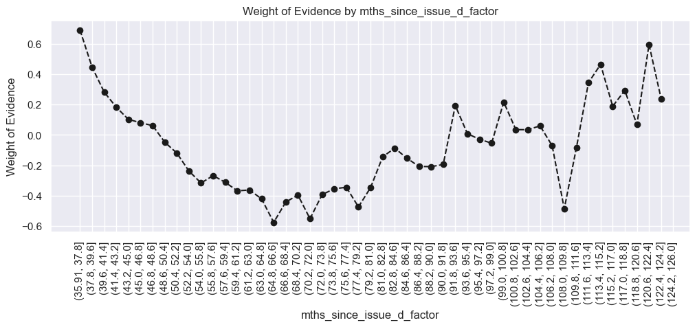

```python
plot_by_woe(df_temp,90)
```

```python
# '< 9.548', '9.548 - 12.025', '12.025 - 15.74', '15.74 - 20.281', '> 20.281'
df_inputs_prepr['int_rate:<9.548'] = np.where((df_inputs_prepr['int_rate'] <= 9.548), 1, 0)
df_inputs_prepr['int_rate:9.548-12.025'] = np.where((df_inputs_prepr['int_rate'] > 9.548) & (df_inputs_prepr['int_rate'] <= 12.025), 1, 0)
df_inputs_prepr['int_rate:12.025-15.74'] = np.where((df_inputs_prepr['int_rate'] > 12.025) & (df_inputs_prepr['int_rate'] <= 15.74), 1, 0)
df_inputs_prepr['int_rate:15.74-20.281'] = np.where((df_inputs_prepr['int_rate'] > 15.74) & (df_inputs_prepr['int_rate'] <= 20.281), 1, 0)
df_inputs_prepr['int_rate:>20.281'] = np.where((df_inputs_prepr['int_rate'] > 20.281), 1, 0)
```

```python
# funded_amnt
df_inputs_prepr['funded_amnt_factor'] = pd.cut(df_inputs_prepr['funded_amnt'], 50)
# Here we do fine-classing: using the 'cut' method, we split the variable into 50 categories by its values.
df_temp = woe_ordered_continuous(df_inputs_prepr, 'funded_amnt_factor', df_targets_prepr)
# We calculate weight of evidence.
df_temp
```

|  | funded_amnt_factor | n_obs | prop_good | prop_n_obs | n_good | n_bad | prop_n_good | prop_n_bad | WoE | diff_prop_good | diff_WoE | IV |
| --- | --- | --- | --- | --- | --- | --- | --- | --- | --- | --- | --- | --- |
| 0 | (465.5, 1190.0] | 1252 | 0.910543 | 0.003356 | 1140.0 | 112.0 | 0.003424 | 0.002796 | 0.202673 | NaN | NaN | 0.015716 |
| 1 | (1190.0, 1880.0] | 3040 | 0.909211 | 0.008150 | 2764.0 | 276.0 | 0.008301 | 0.006889 | 0.186421 | 0.001333 | 0.016251 | 0.015716 |
| 2 | (1880.0, 2570.0] | 6025 | 0.901245 | 0.016152 | 5430.0 | 595.0 | 0.016308 | 0.014852 | 0.093521 | 0.007966 | 0.092900 | 0.015716 |
| 3 | (2570.0, 3260.0] | 7261 | 0.894780 | 0.019465 | 6497.0 | 764.0 | 0.019513 | 0.019070 | 0.022916 | 0.006464 | 0.070605 | 0.015716 |
| 4 | (3260.0, 3950.0] | 4789 | 0.898726 | 0.012838 | 4304.0 | 485.0 | 0.012926 | 0.012106 | 0.065539 | 0.003946 | 0.042623 | 0.015716 |
| 5 | (3950.0, 4640.0] | 9015 | 0.894620 | 0.024167 | 8065.0 | 950.0 | 0.024222 | 0.023713 | 0.021215 | 0.004106 | 0.044324 | 0.015716 |
| 6 | (4640.0, 5330.0] | 15865 | 0.897195 | 0.042530 | 14234.0 | 1631.0 | 0.042749 | 0.040712 | 0.048828 | 0.002575 | 0.027613 | 0.015716 |
| 7 | (5330.0, 6020.0] | 17138 | 0.908799 | 0.045943 | 15575.0 | 1563.0 | 0.046777 | 0.039015 | 0.181448 | 0.011604 | 0.132620 | 0.015716 |
| 8 | (6020.0, 6710.0] | 6926 | 0.887237 | 0.018567 | 6145.0 | 781.0 | 0.018455 | 0.019495 | -0.054793 | 0.021563 | 0.236241 | 0.015716 |
| 9 | (6710.0, 7400.0] | 11726 | 0.900307 | 0.031435 | 10557.0 | 1169.0 | 0.031706 | 0.029180 | 0.083028 | 0.013071 | 0.137822 | 0.015716 |
| 10 | (7400.0, 8090.0] | 17572 | 0.898133 | 0.047106 | 15782.0 | 1790.0 | 0.047398 | 0.044681 | 0.059042 | 0.002174 | 0.023986 | 0.015716 |
| 11 | (8090.0, 8780.0] | 6366 | 0.885485 | 0.017066 | 5637.0 | 729.0 | 0.016930 | 0.018197 | -0.072179 | 0.012648 | 0.131221 | 0.015716 |
| 12 | (8780.0, 9470.0] | 9184 | 0.886433 | 0.024620 | 8141.0 | 1043.0 | 0.024450 | 0.026035 | -0.062800 | 0.000948 | 0.009378 | 0.015716 |
| 13 | (9470.0, 10160.0] | 33703 | 0.897160 | 0.090350 | 30237.0 | 3466.0 | 0.090811 | 0.086516 | 0.048453 | 0.010728 | 0.111253 | 0.015716 |
| 14 | (10160.0, 10850.0] | 6745 | 0.871164 | 0.018082 | 5876.0 | 869.0 | 0.017647 | 0.021691 | -0.206324 | 0.025997 | 0.254777 | 0.015716 |
| 15 | (10850.0, 11540.0] | 8504 | 0.887465 | 0.022797 | 7547.0 | 957.0 | 0.022666 | 0.023888 | -0.052510 | 0.016301 | 0.153814 | 0.015716 |
| 16 | (11540.0, 12230.0] | 23344 | 0.903230 | 0.062580 | 21085.0 | 2259.0 | 0.063325 | 0.056388 | 0.116028 | 0.015765 | 0.168538 | 0.015716 |
| 17 | (12230.0, 12920.0] | 4782 | 0.875575 | 0.012819 | 4187.0 | 595.0 | 0.012575 | 0.014852 | -0.166434 | 0.027655 | 0.282461 | 0.015716 |
| 18 | (12920.0, 13610.0] | 7294 | 0.898273 | 0.019553 | 6552.0 | 742.0 | 0.019678 | 0.018521 | 0.060564 | 0.022697 | 0.226998 | 0.015716 |
| 19 | (13610.0, 14300.0] | 8177 | 0.894093 | 0.021921 | 7311.0 | 866.0 | 0.021957 | 0.021616 | 0.015638 | 0.004179 | 0.044926 | 0.015716 |
| 20 | (14300.0, 14990.0] | 5148 | 0.879371 | 0.013801 | 4527.0 | 621.0 | 0.013596 | 0.015501 | -0.131128 | 0.014723 | 0.146767 | 0.015716 |
| 21 | (14990.0, 15680.0] | 21805 | 0.901536 | 0.058454 | 19658.0 | 2147.0 | 0.059039 | 0.053592 | 0.096801 | 0.022166 | 0.227929 | 0.015716 |
| 22 | (15680.0, 16370.0] | 11708 | 0.881790 | 0.031386 | 10324.0 | 1384.0 | 0.031006 | 0.034546 | -0.108119 | 0.019746 | 0.204919 | 0.015716 |
| 23 | (16370.0, 17060.0] | 6539 | 0.874446 | 0.017530 | 5718.0 | 821.0 | 0.017173 | 0.020493 | -0.176761 | 0.007345 | 0.068642 | 0.015716 |
| 24 | (17060.0, 17750.0] | 3502 | 0.866077 | 0.009388 | 3033.0 | 469.0 | 0.009109 | 0.011707 | -0.250907 | 0.008369 | 0.074147 | 0.015716 |
| 25 | (17750.0, 18440.0] | 11506 | 0.884147 | 0.030845 | 10173.0 | 1333.0 | 0.030553 | 0.033273 | -0.085307 | 0.018071 | 0.165600 | 0.015716 |
| 26 | (18440.0, 19130.0] | 3880 | 0.866495 | 0.010401 | 3362.0 | 518.0 | 0.010097 | 0.012930 | -0.247296 | 0.017653 | 0.161989 | 0.015716 |
| 27 | (19130.0, 19820.0] | 4078 | 0.862433 | 0.010932 | 3517.0 | 561.0 | 0.010563 | 0.014003 | -0.281969 | 0.004062 | 0.034673 | 0.015716 |
| 28 | (19820.0, 20510.0] | 20200 | 0.901436 | 0.054151 | 18209.0 | 1991.0 | 0.054687 | 0.049698 | 0.095667 | 0.039003 | 0.377636 | 0.015716 |
| 29 | (20510.0, 21200.0] | 6697 | 0.895177 | 0.017953 | 5995.0 | 702.0 | 0.018005 | 0.017523 | 0.027136 | 0.006259 | 0.068531 | 0.015716 |
| 30 | (21200.0, 21890.0] | 2029 | 0.850172 | 0.005439 | 1725.0 | 304.0 | 0.005181 | 0.007588 | -0.381658 | 0.045004 | 0.408793 | 0.015716 |
| 31 | (21890.0, 22580.0] | 4108 | 0.891918 | 0.011013 | 3664.0 | 444.0 | 0.011004 | 0.011083 | -0.007126 | 0.041746 | 0.374532 | 0.015716 |
| 32 | (22580.0, 23270.0] | 2483 | 0.890052 | 0.006656 | 2210.0 | 273.0 | 0.006637 | 0.006814 | -0.026336 | 0.001866 | 0.019210 | 0.015716 |
| 33 | (23270.0, 23960.0] | 1871 | 0.849813 | 0.005016 | 1590.0 | 281.0 | 0.004775 | 0.007014 | -0.384478 | 0.040239 | 0.358141 | 0.015716 |
| 34 | (23960.0, 24650.0] | 9874 | 0.904092 | 0.026470 | 8927.0 | 947.0 | 0.026811 | 0.023638 | 0.125924 | 0.054279 | 0.510402 | 0.015716 |
| 35 | (24650.0, 25340.0] | 10029 | 0.896002 | 0.026885 | 8986.0 | 1043.0 | 0.026988 | 0.026035 | 0.035955 | 0.008090 | 0.089970 | 0.015716 |
| 36 | (25340.0, 26030.0] | 1895 | 0.863852 | 0.005080 | 1637.0 | 258.0 | 0.004916 | 0.006440 | -0.269951 | 0.032149 | 0.305906 | 0.015716 |
| 37 | (26030.0, 26720.0] | 1223 | 0.841374 | 0.003279 | 1029.0 | 194.0 | 0.003090 | 0.004842 | -0.449128 | 0.022479 | 0.179176 | 0.015716 |
| 38 | (26720.0, 27410.0] | 1562 | 0.868758 | 0.004187 | 1357.0 | 205.0 | 0.004075 | 0.005117 | -0.227590 | 0.027384 | 0.221537 | 0.015716 |
| 39 | (27410.0, 28100.0] | 6426 | 0.906007 | 0.017227 | 5822.0 | 604.0 | 0.017485 | 0.015077 | 0.148213 | 0.037249 | 0.375803 | 0.015716 |
| 40 | (28100.0, 28790.0] | 805 | 0.857143 | 0.002158 | 690.0 | 115.0 | 0.002072 | 0.002871 | -0.325853 | 0.048864 | 0.474065 | 0.015716 |
| 41 | (28790.0, 29480.0] | 1182 | 0.867174 | 0.003169 | 1025.0 | 157.0 | 0.003078 | 0.003919 | -0.241410 | 0.010031 | 0.084443 | 0.015716 |
| 42 | (29480.0, 30170.0] | 7186 | 0.883941 | 0.019264 | 6352.0 | 834.0 | 0.019077 | 0.020818 | -0.087321 | 0.016767 | 0.154090 | 0.015716 |
| 43 | (30170.0, 30860.0] | 570 | 0.824561 | 0.001528 | 470.0 | 100.0 | 0.001412 | 0.002496 | -0.570050 | 0.059380 | 0.482729 | 0.015716 |
| 44 | (30860.0, 31550.0] | 863 | 0.871379 | 0.002313 | 752.0 | 111.0 | 0.002258 | 0.002771 | -0.204406 | 0.046818 | 0.365644 | 0.015716 |
| 45 | (31550.0, 32240.0] | 1361 | 0.887583 | 0.003649 | 1208.0 | 153.0 | 0.003628 | 0.003819 | -0.051329 | 0.016204 | 0.153077 | 0.015716 |
| 46 | (32240.0, 32930.0] | 619 | 0.875606 | 0.001659 | 542.0 | 77.0 | 0.001628 | 0.001922 | -0.166152 | 0.011977 | 0.114823 | 0.015716 |
| 47 | (32930.0, 33620.0] | 1123 | 0.894034 | 0.003010 | 1004.0 | 119.0 | 0.003015 | 0.002970 | 0.015012 | 0.018428 | 0.181163 | 0.015716 |
| 48 | (33620.0, 34310.0] | 500 | 0.886000 | 0.001340 | 443.0 | 57.0 | 0.001330 | 0.001423 | -0.067094 | 0.008034 | 0.082105 | 0.015716 |
| 49 | (34310.0, 35000.0] | 13548 | 0.882123 | 0.036319 | 11951.0 | 1597.0 | 0.035893 | 0.039863 | -0.104924 | 0.003877 | 0.037830 | 0.015716 |

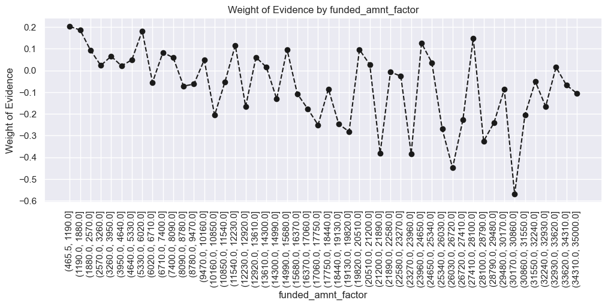

```python
plot_by_woe(df_temp, 90)
# We plot the weight of evidence values.
```

```python
# mths_since_earliest_cr_line
df_inputs_prepr['mths_since_earliest_cr_line_factor'] = pd.cut(df_inputs_prepr['mths_since_earliest_cr_line'], 50)
# Here we do fine-classing: using the 'cut' method, we split the variable into 50 categories by its values.
df_temp = woe_ordered_continuous(df_inputs_prepr, 'mths_since_earliest_cr_line_factor', df_targets_prepr)
# We calculate weight of evidence.
df_temp
```

|  | mths_since_earliest_cr_line_factor | n_obs | prop_good | prop_n_obs | n_good | n_bad | prop_n_good | prop_n_bad | WoE | diff_prop_good | diff_WoE | IV |
| --- | --- | --- | --- | --- | --- | --- | --- | --- | --- | --- | --- | --- |
| 0 | (-0.587, 11.74] | 26 | 1.000000 | 0.000070 | 26.0 | 0.0 | 0.000078 | 0.000000 | inf | NaN | NaN | inf |
| 1 | (11.74, 23.48] | 0 | NaN | 0.000000 | NaN | NaN | NaN | NaN | NaN | NaN | NaN | inf |
| 2 | (23.48, 35.22] | 0 | NaN | 0.000000 | NaN | NaN | NaN | NaN | NaN | NaN | NaN | inf |
| 3 | (35.22, 46.96] | 0 | NaN | 0.000000 | NaN | NaN | NaN | NaN | NaN | NaN | NaN | inf |
| 4 | (46.96, 58.7] | 0 | NaN | 0.000000 | NaN | NaN | NaN | NaN | NaN | NaN | NaN | inf |
| 5 | (58.7, 70.44] | 0 | NaN | 0.000000 | NaN | NaN | NaN | NaN | NaN | NaN | NaN | inf |
| 6 | (70.44, 82.18] | 738 | 0.906504 | 0.001978 | 669.0 | 69.0 | 0.002009 | 0.001722 | 0.154065 | NaN | NaN | inf |
| 7 | (82.18, 93.92] | 1931 | 0.890730 | 0.005177 | 1720.0 | 211.0 | 0.005166 | 0.005267 | -0.019391 | 0.015774 | 0.173456 | inf |
| 8 | (93.92, 105.66] | 2845 | 0.854482 | 0.007627 | 2431.0 | 414.0 | 0.007301 | 0.010334 | -0.347420 | 0.036249 | 0.328029 | inf |
| 9 | (105.66, 117.4] | 5097 | 0.871101 | 0.013664 | 4440.0 | 657.0 | 0.013335 | 0.016400 | -0.206886 | 0.016619 | 0.140534 | inf |
| 10 | (117.4, 129.14] | 9253 | 0.868151 | 0.024805 | 8033.0 | 1220.0 | 0.024126 | 0.030453 | -0.232905 | 0.002950 | 0.026018 | inf |
| 11 | (129.14, 140.88] | 11672 | 0.869174 | 0.031290 | 10145.0 | 1527.0 | 0.030469 | 0.038116 | -0.223936 | 0.001023 | 0.008969 | inf |
| 12 | (140.88, 152.62] | 13487 | 0.881219 | 0.036155 | 11885.0 | 1602.0 | 0.035694 | 0.039988 | -0.113588 | 0.012045 | 0.110348 | inf |
| 13 | (152.62, 164.36] | 16197 | 0.880163 | 0.043420 | 14256.0 | 1941.0 | 0.042815 | 0.048450 | -0.123638 | 0.001056 | 0.010050 | inf |
| 14 | (164.36, 176.1] | 19251 | 0.887538 | 0.051607 | 17086.0 | 2165.0 | 0.051315 | 0.054041 | -0.051773 | 0.007375 | 0.071864 | inf |
| 15 | (176.1, 187.84] | 20474 | 0.889909 | 0.054886 | 18220.0 | 2254.0 | 0.054720 | 0.056263 | -0.027799 | 0.002371 | 0.023974 | inf |
| 16 | (187.84, 199.58] | 26360 | 0.886381 | 0.070665 | 23365.0 | 2995.0 | 0.070172 | 0.074759 | -0.063317 | 0.003528 | 0.035519 | inf |
| 17 | (199.58, 211.32] | 28350 | 0.887972 | 0.076000 | 25174.0 | 3176.0 | 0.075605 | 0.079277 | -0.047423 | 0.001591 | 0.015894 | inf |
| 18 | (211.32, 223.06] | 27041 | 0.888244 | 0.072491 | 24019.0 | 3022.0 | 0.072136 | 0.075433 | -0.044686 | 0.000272 | 0.002737 | inf |
| 19 | (223.06, 234.8] | 22051 | 0.890799 | 0.059114 | 19643.0 | 2408.0 | 0.058994 | 0.060107 | -0.018688 | 0.002555 | 0.025998 | inf |
| 20 | (234.8, 246.54] | 19746 | 0.889800 | 0.052934 | 17570.0 | 2176.0 | 0.052768 | 0.054316 | -0.028908 | 0.000998 | 0.010220 | inf |
| 21 | (246.54, 258.28] | 18113 | 0.895600 | 0.048557 | 16222.0 | 1891.0 | 0.048720 | 0.047202 | 0.031650 | 0.005799 | 0.060558 | inf |
| 22 | (258.28, 270.02] | 17817 | 0.896672 | 0.047763 | 15976.0 | 1841.0 | 0.047981 | 0.045954 | 0.043167 | 0.001072 | 0.011516 | inf |
| 23 | (270.02, 281.76] | 14765 | 0.901321 | 0.039581 | 13308.0 | 1457.0 | 0.039968 | 0.036369 | 0.094374 | 0.004649 | 0.051207 | inf |
| 24 | (281.76, 293.5] | 14206 | 0.902576 | 0.038083 | 12822.0 | 1384.0 | 0.038508 | 0.034546 | 0.108572 | 0.001256 | 0.014199 | inf |
| 25 | (293.5, 305.24] | 10349 | 0.907334 | 0.027743 | 9390.0 | 959.0 | 0.028201 | 0.023938 | 0.163897 | 0.004758 | 0.055325 | inf |
| 26 | (305.24, 316.98] | 7721 | 0.906877 | 0.020698 | 7002.0 | 719.0 | 0.021029 | 0.017947 | 0.158478 | 0.000457 | 0.005420 | inf |
| 27 | (316.98, 328.72] | 8452 | 0.904165 | 0.022658 | 7642.0 | 810.0 | 0.022951 | 0.020219 | 0.126768 | 0.002713 | 0.031709 | inf |
| 28 | (328.72, 340.46] | 8371 | 0.905985 | 0.022441 | 7584.0 | 787.0 | 0.022777 | 0.019645 | 0.147956 | 0.001820 | 0.021187 | inf |
| 29 | (340.46, 352.2] | 7267 | 0.904225 | 0.019481 | 6571.0 | 696.0 | 0.019735 | 0.017373 | 0.127460 | 0.001760 | 0.020496 | inf |
| 30 | (352.2, 363.94] | 5638 | 0.911493 | 0.015114 | 5139.0 | 499.0 | 0.015434 | 0.012456 | 0.214396 | 0.007269 | 0.086936 | inf |
| 31 | (363.94, 375.68] | 5405 | 0.912118 | 0.014490 | 4930.0 | 475.0 | 0.014806 | 0.011857 | 0.222167 | 0.000625 | 0.007772 | inf |
| 32 | (375.68, 387.42] | 4664 | 0.913808 | 0.012503 | 4262.0 | 402.0 | 0.012800 | 0.010034 | 0.243430 | 0.001689 | 0.021262 | inf |
| 33 | (387.42, 399.16] | 4162 | 0.907496 | 0.011157 | 3777.0 | 385.0 | 0.011344 | 0.009610 | 0.165830 | 0.006311 | 0.077600 | inf |
| 34 | (399.16, 410.9] | 3452 | 0.906721 | 0.009254 | 3130.0 | 322.0 | 0.009400 | 0.008038 | 0.156625 | 0.000776 | 0.009205 | inf |
| 35 | (410.9, 422.64] | 3113 | 0.911340 | 0.008345 | 2837.0 | 276.0 | 0.008520 | 0.006889 | 0.212489 | 0.004619 | 0.055865 | inf |
| 36 | (422.64, 434.38] | 2227 | 0.911540 | 0.005970 | 2030.0 | 197.0 | 0.006097 | 0.004917 | 0.214975 | 0.000201 | 0.002486 | inf |
| 37 | (434.38, 446.12] | 1742 | 0.928243 | 0.004670 | 1617.0 | 125.0 | 0.004856 | 0.003120 | 0.442402 | 0.016703 | 0.227427 | inf |
| 38 | (446.12, 457.86] | 1442 | 0.914702 | 0.003866 | 1319.0 | 123.0 | 0.003961 | 0.003070 | 0.254833 | 0.013542 | 0.187569 | inf |
| 39 | (457.86, 469.6] | 1584 | 0.911616 | 0.004246 | 1444.0 | 140.0 | 0.004337 | 0.003495 | 0.215918 | 0.003086 | 0.038915 | inf |
| 40 | (469.6, 481.34] | 1544 | 0.912565 | 0.004139 | 1409.0 | 135.0 | 0.004232 | 0.003370 | 0.227749 | 0.000949 | 0.011831 | inf |
| 41 | (481.34, 493.08] | 1247 | 0.908581 | 0.003343 | 1133.0 | 114.0 | 0.003403 | 0.002846 | 0.178814 | 0.003984 | 0.048935 | inf |
| 42 | (493.08, 504.82] | 868 | 0.925115 | 0.002327 | 803.0 | 65.0 | 0.002412 | 0.001622 | 0.396355 | 0.016535 | 0.217542 | inf |
| 43 | (504.82, 516.56] | 758 | 0.912929 | 0.002032 | 692.0 | 66.0 | 0.002078 | 0.001647 | 0.232319 | 0.012186 | 0.164036 | inf |
| 44 | (516.56, 528.3] | 620 | 0.911290 | 0.001662 | 565.0 | 55.0 | 0.001697 | 0.001373 | 0.211880 | 0.001638 | 0.020439 | inf |
| 45 | (528.3, 540.04] | 595 | 0.914286 | 0.001595 | 544.0 | 51.0 | 0.001634 | 0.001273 | 0.249511 | 0.002995 | 0.037631 | inf |
| 46 | (540.04, 551.78] | 499 | 0.913828 | 0.001338 | 456.0 | 43.0 | 0.001370 | 0.001073 | 0.243681 | 0.000458 | 0.005831 | inf |
| 47 | (551.78, 563.52] | 339 | 0.914454 | 0.000909 | 310.0 | 29.0 | 0.000931 | 0.000724 | 0.251664 | 0.000627 | 0.007984 | inf |
| 48 | (563.52, 575.26] | 342 | 0.900585 | 0.000917 | 308.0 | 34.0 | 0.000925 | 0.000849 | 0.086127 | 0.013869 | 0.165537 | inf |
| 49 | (575.26, 587.0] | 1207 | 0.879867 | 0.003236 | 1062.0 | 145.0 | 0.003190 | 0.003619 | -0.126437 | 0.020717 | 0.212564 | inf |

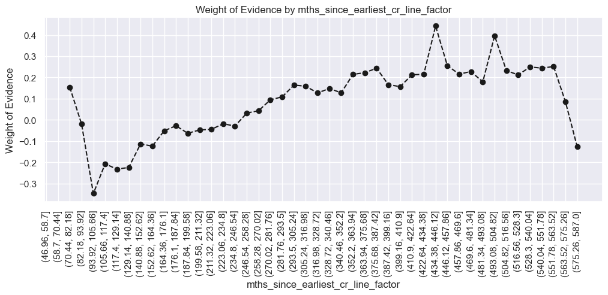

```python
plot_by_woe(df_temp, 90)
# We plot the weight of evidence values.
```